# Sensitive and reproducible cell-free methylome quantification with synthetic spike-in controls: Associated code

# Preprocessing

Scripts are ordered in the order in which they are used. While preprocessing scripts will point to one particular set of sample in the manuscript. The same scripts were used for all samples.

## **01_fastp_bowtie2.sh**

This script will assess quality of the reads using [fastqc](https://www.bioinformatics.babraham.ac.uk/projects/fastqc/).

Adapter trimming and extraction of unique molecular index (UMI) sequences are done using [fastp](https://academic.oup.com/bioinformatics/article/34/17/i884/5093234?login=true).

Alignment to the human genome (hg38) and spike-in control sequences is completed with [Bowtie2](https://www.nature.com/articles/nmeth.1923?report=reader). The fasta file containing our synthetic DNA sequences is located in this github repository.

UMI deduplication is performed with [UMI-tools](https://genome.cshlp.org/content/27/3/491.short).

```bash
#!/usr/bin/env bash
set -euo pipefail
IFS=$'\n\t'
set -e
set -u
set -o pipefail
set -o nounset
set -o errexit

#Loading all needed modules
##This script was adapted from Roxana Shen's MEDIPS_PE_pipe.sh script by SLW
module load parallel
#module load fastp/0.19.4
module load fastqc/0.11.5
module load bowtie2/2.3.5
module load samtools/1.3.1
module load picard/2.10.9
module load bedtools/2.27.1
module load igenome-human/hg38

#mkdir data/2019_TrimmedControls/ #To store the trimmed files in later
##Make sure this is storing data sile in the working directory and not on mordor

#Checking to see what the quality of the unaligned reads are.
parallel -j 6 "fastqc -o data/2019_SpikeInControl_data --noextract -f fastq {1}" ::: data/2019_SpikeInControl_data/*.gz

##fastp- trimming the adapters and appending UMI to sample same
## -i input of read 1
## -I input of read 2
## -o output of read 1
## -O output of read 2
## --linksm read 1 and read 2
## fastp automatically gzips outputs
parallel -j 6 --link "fastp -i {1} -I {2} -o data/2019_TrimmedControls/trimmed.{1/} -O data/2019_TrimmedControls/trimmed.{2/} --umi --umi_loc=per_read --umi_len=5 --adapter_sequence=AATGATACGGCGACCACCGAGATCTACACATATGCGCACACTCTTTCCCTACACGAC --adapter_sequence_r2=CAAGCAGAAGACGGCATACGAGATACGATCAGGTGACTGGAGTTCAGACGTGT -j data/2019_TrimmedControls/{1/.}.{2/.}.json -h data/2019_TrimmedControls/{1/.}.{2/.}.html" ::: data/2019_SpikeInControl_data/*R1*fastq.gz ::: data/2019_SpikeInControl_data/*R2*fastq.gz

##Align reads to reference genome
### Create my own index to align to the synthetic fragment sequences located in the path where bowtie2 is located
#bowtie2-build -f SyntheticDNA_seq.fasta  SyntheticDNA_idx

### -f specifies the reference genome to be used, fastq file
### -p specifies the number of threads to be used in parallelization
### --minins specifies the minimum valid fragment length required for paired end sequence- I have removed a min, as I have 80bp control fragments I want to pick up.
### --maxins specifies the maximum valid fragment length required for paired end sequence
### -q specifies the input fastq read files to be aligned, -1 specified first mate pair, -2 specifies second mate pair
### -S writes the alignment results to a sam file as output
### --no-unal suppresses SAM files for reads that failed to align
### --un will write unaligned reads to a fastq file

#mkdir data/2019_ControlAlignment/ #To store both aligned and unaligned files

##Aligns sequences to control fragments
parallel -j 6 --link "bowtie2 --local -x ./SyntheticDNA_idx -p 6 --minins 80 --maxins 320 --no-unal --un-conc-gz data/2019_ControlAlignment/unalignedtospike.{1/} -q -1 {1} -2 {2} -S data/2019_ControlAlignment/aligned.{1/.}{2/.}.sam 2> data/2019_ControlAlignment/{1/.}_bowtie2.log"  ::: data/2019_TrimmedControls/*R1*.fastq.gz ::: data/2019_TrimmedControls/*R2*.fastq.gz

##Now align to remaining sequencing to the human genome
parallel -j 6 --link "bowtie2 --local -x $BOWTIE2INDEX -p 6 --minins 80 --maxins 320 -q -1 {1} -2 {2} -S data/2019_ControlAlignment/human.aligned.{1/.}{2/.}.sam 2> data/2019_ControlAlignment/{1/.}_bowtie2.log" ::: data/2019_ControlAlignment/unalignedtospike*fastq.1.gz ::: data/2019_ControlAlignment/unalignedtospike*fastq.2.gz

#Convert .sam to .bam files
parallel -j 6 "samtools view -bSh {1} > data/2019_ControlAlignment/{1/.}.bam" ::: data/2019_ControlAlignment/*.sam
## I have not sorted or indexed these files as they are synthetic DNA fragments not aligning to human genome, therefore have no coordinates. Because this is a small file, indexing is not needed.

##Mapping info
parallel -j 6 "samtools flagstat {1} 2> mappinginfo_{1/.}.log" ::: data/2019_ControlAlignment/*.bam

##Filtering reads to only those that were mater properly and counting the number of overlap between reads tha reference sequence (this should be read counts)
parallel -j 6 "samtools view -bf 0x2 {1} > data/2019_ControlAlignment/filtered_{1/.}.bam" ::: data/2019_ControlAlignment/*.bam

#sort bam
### This something has a parallelization issue, so watch that this is correct
parallel -j 12 "samtools sort {1} {1.}_sorted" ::: /mnt/work1/users/home2/wilsons/Projects/2018_PTB/data/2019_ControlAlignment/*.bam

#index bam files
parallel -j 12 "samtools index {1}" ::: /mnt/work1/users/home2/wilsons/Projects/2018_PTB/data/2019_ControlAlignment/*sorted.bam

##UMI dedup
parallel -j 12 "umi_tools dedup -I {1} --paired -S {1.}_dedup.bam --output-stats={1.}_stats.tsv --mapping-quality=20 --unpaired-reads=discard --chimeric-pairs=discard --log={1.}.log" ::: /cluster/projects/hoffmangroup/data_samanthawilson/2020_0.01ng_HCT116/*sorted.bam
```

## **02_GLM_spikes.R**

The script takes the spike-in control bed files and assess methylation specificity and uses read counts, fragment length, G+C content, and number of CpGs in fragment to create a gaussian generalized linear model to calculate molar amount of cell-free DNA in picomoles.

```r
#!/usr/bin/env R

#Load libraries
library(rmarkdown)
library(plyr)
library(dplyr)
library(reshape2)
library(ggplot2)
library(boot)
library(BlandAltmanLeh)
library(scales)
library(stringr)
library(forcats)
library(ggpubr)

##Load data

S6547 <- read.table("/cluster/projects/hoffmangroup/data_samanthawilson/2020_0.01ng_HCT116/filtered_aligned.trimmed.6547_S3_L_R1_001.fastqtrimmed.6547_S3_L_R2_001.fastq_sorted_dedup_sort.bed")
S6547 <- as.data.frame(S6547[,1])
colnames(S6547) <- c("frag_grp")

#Assess methylation specificity and subset to only methylated fragments for GLM
S6547$methylation_status <- str_extract(S6547$frag_grp, "meth")
S6547$methylation_status <- S6547$methylation_status %>% fct_explicit_na(na_level = 'unmeth')

print(sum(S6547$methylation_status == "meth")/nrow(S6547))
# 0.9724638

S6547 <- subset(S6547, S6547$methylation_status == "meth")
S6547$methylation_status <- droplevels(S6547$methylation_status)
S6547$S6547_read_count <- 1

#Aggregate by spike-in control fragment (frag_grp)
S6547 <- S6547 %>%
        group_by(frag_grp) %>%
        summarise(S6547_read_count = sum(S6547_read_count))

S6548 <- read.table("/cluster/projects/hoffmangroup/data_samanthawilson/2020_0.01ng_HCT116/filtered_aligned.trimmed.6548_S4_L_R1_001.fastqtrimmed.6548_S4_L_R2_001.fastq_sorted_dedup_sort.bed")
S6548 <- as.data.frame(S6548[,1])
colnames(S6548) <- c("frag_grp")

#Assess methylation specificity and subset to only methylated fragments for GLM
S6548$methylation_status <- str_extract(S6548$frag_grp, "meth")
S6548$methylation_status <- S6548$methylation_status %>% fct_explicit_na(na_level = 'unmeth')

print(sum(S6548$methylation_status == "meth")/nrow(S6548))
#0.9783167

S6548 <- subset(S6548, S6548$methylation_status == "meth")
S6548$methylation_status <- droplevels(S6548$methylation_status)
S6548$S6548_read_count <- 1

#Aggregate by spike-in control fragment (frag_grp)
S6548 <- S6548 %>%
        group_by(frag_grp) %>%
        summarise(S6548_read_count = sum(S6548_read_count))


##merge
data <- merge(S6547, S6548, by= "frag_grp", all = TRUE)

##fill in NAs from UMI data
data$fragment_len <- as.factor(str_sub(data$frag_grp, 0, 3))
data$fragment_len <- revalue(data$fragment_len, c("80b" = "80"))

data$CpG <- as.factor(str_sub(data$frag_grp, 5, 7))
data$CpG <- revalue(data$CpG, c("_16" = "16","_2C" = "2","_4C" = "4","_8C" = "8","1C_" = "1","2C_" = "2","4C_" = "4"))

data$GC <- as.factor(str_sub(data$frag_grp, 7, 11))
data$GC <- revalue(data$GC, c("_35G-" = "35", "_50G-" = "50", "_65G-" = "65", "6C_35" = "35", "6C_50" = "50", "6C_65"="65", "C_35G"="35", "C_50G" = "50", "C_65G" = "65"))

data$grp <- as.factor(paste0(data$fragment_len, sep = '_', data$CpG,sep = '_', data$GC))

##since initial 320bp, 65% G+C is not correct, let's correct that to correct G+C content
data$grp <- revalue(data$grp, c("320_4_65" = "320_04_35"))
data$grp <- revalue(data$grp, c("320_8_65" = "320_08_50"))
data$grp <- revalue(data$grp, c("320_16_65" = "320_016_50"))

##Fix to the correct GC
data$GC <- as.factor(str_sub(data$grp,-2,-1))

data <- as.data.frame(data)

##Add in concentration information
for (i in 1:nrow(data)){
  data[i,8] <- ifelse (data[i,4] == "160", 0.002, ifelse(data[i,4] == "80", 0.004, 0.001))
}

names(data)[8] <- "conc"

##Adjusting for the 0.01ng dilution
data$conc <- data$conc*0.9

##Some exploratory plots
###Melt so that data frame
data_melt <- melt(data, id.vars = c("conc", "grp", "GC", "CpG", "fragment_len"), measure.vars = c("S6547_read_count", "S6548_read_count"))
data_melt$value <- as.numeric(as.character(data_melt$value))

png("2020_concvsreads_dedup_0.01ng.png", height = 6, width = 6, units = "in", res = 300)
ggplot(data_melt, aes(x = conc, y = value)) + geom_point() +
  theme_bw()+
  theme(axis.title = element_text(size = 20), axis.text.x  = element_text(angle = 45, vjust = 0.5, size = 12), axis.text.y = element_text(vjust = 0.5, size = 12))+
  xlab("Concentration (pmol/ng)")+
  ylab("Read counts")+
  scale_y_continuous(labels = comma)+
  scale_fill_manual("slategray3")
dev.off()

##Colour points by GC content
data$GC <- as.factor(data$GC)

png("2020_concvsreads_dedup_GCcol_0.01ng.png", height = 6, width = 6, units = "in", res = 300)
ggplot(data_melt, aes(x = conc, y = value, col = GC)) + geom_point() +
  theme_bw()+
  theme(axis.title = element_text(size = 20), axis.text.x  = element_text(angle = 45, vjust = 0.5, size = 12), axis.text.y = element_text(vjust = 0.5, size = 12))+
  xlab("Concentration (pmol/ng)")+
  ylab("Read counts")+
  scale_y_continuous(labels = comma)
dev.off()

data$GC <- as.numeric(as.character(data$GC))

##Correlation between read count and concentration
cor(data_melt$conc, data_melt$value)#-0.0956277

##Cube root CpG to try to return distribution to normality
data$CpG <- as.integer(as.character(data$CpG))
data$CpG_3 <- data$CpG ^(1/3)

##cube root
data_sub <- data[, c("frag_grp", "S6547_read_count", "S6548_read_count", "fragment_len", "CpG_3", "GC", "conc")]
data_melt <- melt(data_sub, id.vars = c("conc", "fragment_len", "CpG_3", "GC", "frag_grp"), measure.vars = c("S6547_read_count", "S6548_read_count"))
data_melt$value <- as.numeric(as.character(data_melt$value))

png("2020_CpG_3_dedup_0.01ng.png", height = 6, width = 6, units = "in", res = 300)
ggplot(data = data_melt, aes(x = CpG_3, y = value, width = 0.1)) +
  geom_bar(stat = "identity", fill = "peachpuff") +
  theme_bw() +
  theme(axis.title = element_text(size = 20), axis.text.x  = element_text(angle = 45, vjust = 0.5, size = 12), axis.text.y = element_text(vjust = 0.5, size = 12)) +
  xlab("Number of CpGs") +
  ylab("Read counts") +
  scale_y_continuous(labels = comma, limits = c(0, 80000), breaks = c(20000, 40000, 60000, 80000))
dev.off()
#better, this will be used

###Let's try out some models now
data$fragment_len <- as.numeric(as.character(data$fragment_len))
data$GC <- as.numeric(as.character(data$GC))

data_sub <- data[, c("frag_grp", "S6547_read_count", "S6548_read_count", "fragment_len", "CpG_3", "GC", "conc")]
data_melt <- melt(data_sub, id.vars = c("conc", "fragment_len", "CpG_3", "GC", "frag_grp"), measure.vars = c("S6547_read_count", "S6548_read_count"))
data_melt$value <- as.numeric(as.character(data_melt$value))

##Set ggplot theme
theme_set(theme_bw() +
  theme(legend.title = element_blank(), legend.position = "right", legend.text = element_text(size = 14),
        axis.title.y = element_text(size = 20), axis.text.x  = element_text(size = 16),
        axis.text.y = element_text(vjust = 0.5, size = 16),axis.title.x = element_text(size = 20))
)


#Make sure the data is in correct format before modelling
stopifnot(str(data_melt$fragment_len) == "num")
stopifnot(str(data$CpG) == "num")
stopifnot(str(data_melt$CpG_3) == "num")
stopifnot(str(data_melt$GC) == "num")

##Poisson
###Poisson- Getting negatives
poisson_glm <- glm(formula = conc ~ value + fragment_len + GC + CpG_3, data = data_melt, family = poisson(link = "log"))
summary(poisson_glm)#In dpois(y, mu, log = TRUE) : non-integer x = 0.000842

##Calculate R2
r2_poisson <- 1 - (poisson_glm$deviance / poisson_glm$null.deviance)
r2_poisson # 0.9829384

png("2020_GLM_fraglen_CpG3_0.01ngdiag.png")
glm.diag.plots(poisson_glm, glmdiag = glm.diag(poisson_glm))
dev.off()

png("2020_GLM_fraglen_CpG3_poisson_0.01ng.png")
plot(poisson_glm)
dev.off()

png("2020_BA_poisson_fraglen_CpG3_0.01ng.png")
bland.altman.plot(poisson_glm$data[,1], poisson_glm$resid, conf.int=.95, pch=19) ##Why are there negative values here
dev.off()

poisson_glm$data[,8] <- as.factor(as.character(poisson_glm$data[, 2]))
names(poisson_glm$data[,8]) <- "Fragment_len"

png("2020_BA_poisson_fraglen_CpG3_0.01ng.png", height = 6, width = 6, units = "in", res = 300)
BA <- bland.altman.plot(poisson_glm$data[,1], poisson_glm$resid, conf.int = .95, col.points = poisson_glm$data[,2], pch = 19, graph.sys = "ggplot2")

BA +
  xlab("Mean of measurements (femotomoles)") +
  ylab("Difference (picomoles)") +
  stat_cor(method = "spearman", label.x.npc = "left", label.y = c(-0.05, -0.06, -0.07)) +
  aes(color = poisson_glm$data[,8]) +
  scale_color_manual(values = c("black", "darkgrey", "navy"))

dev.off()

###Gaussian
gaussian_glm <- glm(formula = conc ~ value + fragment_len + GC + CpG_3, data = data_melt, family = gaussian)
summary(gaussian_glm)

png("2020_GLM_gaussian_fraglen_CpG3_0.01ngdiag.png")
glm.diag.plots(gaussian_glm, glmdiag = glm.diag(gaussian_glm))
dev.off()

png("2020_GLM_fraglen_CpG3_gaussian0.01ng.png")
plot(gaussian_glm)
dev.off()

png("2020_BA_gaussian_fraglen_CpG30.01ng.png")
bland.altman.plot(gaussian_glm$data[,1], gaussian_glm$resid, conf.int=.95, pch=19)
dev.off()

gaussian_glm$data[,8] <- as.factor(as.character(gaussian_glm$data[, 2]))
names(gaussian_glm$data[,8]) <- "Fragment_len"

png("2020_BA_gaussian_fraglen_CpG3_0.01ng.png", height = 6, width = 6, units = "in", res = 300)
BA <- bland.altman.plot(gaussian_glm$data[,1], gaussian_glm$resid, conf.int = .95, col.points = gaussian_glm$data[,2], pch = 19, graph.sys = "ggplot2")

BA +
  xlab("Mean of measurements (femotomoles)") +
  ylab("Difference (picomoles)") +
  stat_cor(method = "spearman", label.x = 0.001, label.y = c(-0.0015, -0.0018, -0.0021)) +
  aes(color = gaussian_glm$data[,8]) +
  scale_color_manual(values = c("black", "darkgrey", "navy"))

dev.off()

##This estimates the 160bp very nicely

##Calculate R2
r2_gaussian= 1-(gaussian_glm$deviance/gaussian_glm$null.deviance)
r2_gaussian #0.9429097

##Correlation isn't great, but makes sense in the context of wanting 160bp to perform better, best AIC I've seen
save(gaussian_glm, file = "2020_Gaussian_0.01ng.rda")

###Gaussian log
gaussian_log <- glm(formula = conc ~ value + fragment_len + GC + CpG_3, data = data_melt, family = gaussian(link = "log"))
summary(gaussian_log)

png("2020_GLM_gaussianlog_fraglen_CpG3_diag_0.01ng.png")
glm.diag.plots(gaussian_log, glmdiag = glm.diag(gaussian_log))
dev.off()

png("2020_GLM_gaussianlog_fraglen_CpG3_0.01ng.png")
plot(gaussian_log)
dev.off()

##Bland-Altman plot (plots the residuals against the truth and looks at the deviance)
#gaussian_log$data[,2]=as.factor(as.character(gaussian_log$data[,2]))
gaussian_log$data[,8] <- as.factor(as.character(gaussian_log$data[,2]))
names(gaussian_log$data[,8]) <- "Fragment_len"

png("2020_BA_guassianlog_fraglen_CpG3_0.01ng.png", height = 6, width = 6, units = "in", res = 300)
BA <- bland.altman.plot(exp(gaussian_log$data[,1]), gaussian_log$resid, conf.int = .95, col.points = gaussian_log$data[,2], pch = 19, graph.sys="ggplot2")

BA +
  xlab("Mean of measurements (femotomoles)") +
  ylab("Difference (picomoles)") +
  stat_cor(method = "spearman", label.x.npc = "left", label.y = c(0.9, 0.88, 0.86)) +
  aes(color = gaussian_log$data[,8]) +
  scale_color_manual(values = c("black", "darkgrey", "navy"))

dev.off()

##Calculate R2
r2_gaussian_log = 1-(gaussian_log$deviance/gaussian_log$null.deviance)
r2_gaussian_log #0.9848901

##Seeing if a simple lm would perform better
lm <- lm(conc ~ value + fragment_len + GC + CpG_3, data = data_melt)
summary(lm)#R2=0.9343, adjusted=0.9287
##residual standard error -0.0005083

png("2020_lm_fraglen_CpG3_0.01ng.png")
plot(lm)
dev.off()

png("2020_lm_fraglen_CpG3_diag_0.01ng.png")
glm.diag.plots(lm, glmdiag = glm.diag(lm))
dev.off()

png("2020_BA_lm_fraglen_CpG3_0.01ng.png")
bland.altman.plot(lm$model[,1], lm$resid, conf.int=.95, pch=19)
dev.off()

lm$model[,6] <- as.factor(as.character(lm$model[,3]))
names(lm$model[,6]) <- "Fragment_len"

png("2020_BA_lm_fraglen_CpG3_0.01ng.png", height = 6, width = 6, units = "in", res = 300)
BA <- bland.altman.plot(lm$model[,1], lm$residuals, conf.int = .95, pch = 19, graph.sys="ggplot2")

BA +
  xlab("Mean of measurements (picomoles)") +
  ylab("Difference (picomoles)") +
  stat_cor(method = "spearman", label.x = 0.0012, label.y = c(0.0016, 0.0014, 0.0012)) +
  aes(color = as.factor(lm$model[, 3])) +
  scale_color_manual(values = c("black", "darkgrey", "navy"))

dev.off()

save(lm, file = "2020_lm_0.01ng.rda")
```

## **03a_calc_frag_params.sh**

This script obtains the coordinates for the cell-free DNA fragment and gets the DNA sequence for that genomics region. I use bedtools nuc to calculate the fragment length, G+C content, and number of CpGs within a fragment.

```bash
#!/usr/bin/env bash
set -euo pipefail
IFS=$'\n\t'
set -e
set -u
set -o pipefail
set -o nounset
set -o errexit

#Loading all needed modules
module load parallel
module load samtools
module load bedtools

#convert deduplicated bam to bedpe
parallel -j 12 "samtools sort -n {1} -o {1.}_sort.bam" ::: /cluster/projects/hoffmangroup/data_samanthawilson/2020_0.01ng_HCT116/*dedup.bam

#convert deduplicated bam to bedpe
parallel -j 12 "bedtools bamtobed -bedpe -i {1}" ::: /cluster/projects/hoffmangroup/data_samanthawilson/2020_0.01ng_HCT116/*dedup.bam

#cut hg38 aligned bed file to only to read 1 start and read 2 end
parallel -j 6 "cut -f1-2,6,7,11- {1} > {1.}_cut.bed" ::: /cluster/projects/hoffmangroup/data_samanthawilson/2020_0.01ng_HCT116/filtered_human*.bed

#calculate GC content, fragment length, and CpG number
## As some CG are capital and some not, I do this twice

parallel -j 6 "bedtools nuc -fi /cluster/projects/hoffmangroup/data_samanthawilson/2020_PTB_secondtri/hg38.fa -bed {1} -pattern CG > {1.}_CG.bed " ::: /cluster/projects/hoffmangroup/data_samanthawilson/2020_0.01ng_HCT116/*_cut.bed

parallel -j 6 "bedtools nuc -fi /cluster/projects/hoffmangroup/data_samanthawilson/2020_PTB_secondtri/hg38.fa -bed {1} -pattern CG > {1.}_cg.bed " ::: /cluster/projects/hoffmangroup/data_samanthawilson/2020_0.01ng_HCT116/*_cut.bed
```

## **03b_restructure_frag_params.sh**

This script combines the information for number of CpGs within a fragment to one file.

This script may not need to be run if you do not have an issue with case sensititvity.

If you do not know whether there is a case sensitivity issue, run this script and there is a check in the *04_predict_pmol.R* script.

```bash
#!/usr/bin/env bash
set -euo pipefail
IFS=$'\n\t'
set -e
set -u
set -o pipefail
set -o nounset
set -o errexit

module load parallel

##Check that the first 3 rows match between the files
parallel -j 6 "awk '{k=$1 FS $2 FS $3 FS $4} NR==FNR{a[k]; next} !(k in a)' {1} {2}" ::: ~/Projects/2018_PTB/data/2019_ControlAlignment/*CG.bed ::: ~/Projects/2018_PTB/data/2019_ControlAlignment/*cg.bed
##event not found, they should match

##Paste last column of cg file to the CG file
parallel -j 1 "cut -f14-14 {1} > {1.}_tmp.bed" ::: ~/Projects/2018_PTB/data/2019_ControlAlignment/*cg.bed

parallel -j 1 "paste {1} {2} > {1.}_all.bed" ::: ~/Projects/2018_PTB/data/2019_ControlAlignment/*CG.bed ::: ~/Projects/2018_PTB/data/2019_ControlAlignment/*tmp.bed

##Make sure to delete tmp files after to save storage
```

## **04_predict_pmol.R**

This script takes the fragment aligned to the human genome and their read count, fragment length, G+C content, and CpG number and calculates the molar amount in picomoles using guassian generalized linear model obtained from *02_GLM_spikes.R*

```r
#!/usr/bin/env Rscript

#Load libraries
library(plyr)
library(dplyr)
library(ggplot2)
library(reshape2)
library(gridExtra)
library(stringr)
library(varhandle)
library(forcats)
library(purrr)
library(stringi)
library(tools)

main <- function(filename) {
    data <- read.table(filename, sep = "\t", stringsAsFactors = TRUE, fill = TRUE)
    data <- data[,c(1:3, 6,13:15)]
    colnames(data) <- c("chr", "start", "end", "GC", "fragment_len", "CpG1", "CpG2")

     ##CpGs have been read in as levels - make sure they are numeric
        data$CpG1 <- as.numeric(as.character(data$CpG1))
        data$CpG2 <- as.numeric(as.character(data$CpG2))

        #Check if CpG1 and CpG2 columns match - if they do, case sentivity in bedtools was not a problem and we only need one column
        #Otherwise, we need to add the columns together
        if (data$CpG1 == data$CpG2) {data$CpG <- data$CpG1} else {data$CpG <- data$CpG1 + data$CpG2}

        print(head(data))
        print(str(data))

    ##define read count as 1 per line
    data$read_count <- 1

    ### remove uncharacterized genomic regions
    data <- as.data.frame(data[!grepl("*KI*", data$chr), ])
    data <- as.data.frame(data[!grepl("*GL*", data$chr), ])
    data <- as.data.frame(data[!grepl("*EBV*", data$chr), ])
    data <- as.data.frame(data[!grepl("*Un*", data$chr), ])

    data_melt <- melt(data,
                  id.vars = c("GC","fragment_len", "CpG", "chr", "start", "end"),
                  measure.vars = "read_count")
    data_melt$value <- as.numeric(as.character(data_melt$value))

    data_melt$CpG_3 <- (data_melt$CpG) ^ (1 / 3)

    data_melt$fragment_len <- as.numeric(data_melt$fragment_len)
        data_melt$GC <- as.numeric(data_melt$GC)
        data_melt$CpG <- as.numeric(data_melt$CpG)

        stopifnot(str(data_melt$fragment_len) == "num")
        stopifnot(str(data_melt$GC) == "num")
        stopifnot(str(data_melt$CpG) == "num")

    ##Source the GLM from the control GLM code
    load("/mnt/work1/users/home2/wilsons/Projects/2018_PTB/data/2019_ControlAlignment/2020_Gaussian_0.01ng.rda")

    print("start pmol prediction")

    ##Predict fmol values
    pred_conc <- as.data.frame(predict(gaussian_glm, data_melt))
    names(pred_conc) <- "value"

     ##Replace value with conc
        data_melt$read_count<- data_melt$value
        data_melt$value <- NULL
        data_melt <- cbind(data_melt, pred_conc)
        data_melt$variable <- NULL
        colnames(data_melt) <- c("GC","fragment_len", "CpG", "chr", "start", "end", "CpG_3", "read_count", "pmol")

    print(head(data_melt))

    #restructure to bed file format
        data_melt <- data_melt[, c("chr", "start", "end", "fragment_len", "GC", "CpG", "CpG_3", "read_count", "pmol")]
        print(head(data_melt))

    write.table(data_melt, spe = "\t", row.names = FALSE, quote = FALSE, file = paste0("~/Projects/2018_PTB/data/2019_ControlAlignment/",
                                       file_path_sans_ext(basename(filename)), "_pmol.bed"))

}

args <-
if (length(commandArgs(TRUE))
    || commandArgs()[length(commandArgs())] == "--args") {
    as.list(commandArgs(TRUE))
} else {
    list()
}

 do.call(main, args)
```

## **05a_overlap_hg38_300bpwindows.sh**

This script takes each of the fragments aligned to the human genome and the calculated molar amount and idenifies which 300bp windows each fragment overlaps.

```bash
#!/usr/bin/env bash
set -euo pipefail
IFS=$'\n\t'
set -e
set -u
set -o pipefail
set -o nounset
set -o errexit

##Find the overlaps between our fragments and each of the 300bp windows in genom
### Retrun a file with the fragment listed, the concentration value for each sample, the window it overlaps and the number of basepairs that it overlaps

module load bedtools
module load parallel


parallel -j 6 "bedtools intersect -wao -a {1} -b /cluster/home/wilsons/Projects/2020_Control_Project/2020_BatchAnalysis/2020_hg38_300bpwindows.bed > {1.}_hg38_intersect.bed" ::: /cluster/projects/hoffmangroup/data_samanthawilson/*pmol.bed
```

## **05b_adjust_pmol_to300bp.R**

This final preprocessing script adjusts the molar amount (picomoles) value to account for the proportion of the fragment that overlaps each 300bp window.

```r
#!/usr/bin/env Rscript

##Load packages
library(plyr)
library(dplyr)
library(ggplot2)
library(reshape2)
library(gridExtra)
library(stringr)
library(varhandle)
library(forcats)
library(purrr)
library(stringi)
library(tidyverse)
library(tools)

main <- function(filename) {

##Load in data
data <- read.table(filename, sep = "\t" , stringsAsFactors = TRUE, fill = TRUE)
colnames(data) <- c("chr_frag", "start_frag", "end_frag", "fragment_len", "GC", "CpG", "CpG_3", "read_count", "pmol", "chrom", "chromStart", "chromEnd", "overlap_bp")

###Adjust the methylation values (overlaps/300*conc)
window_size <- 300

data$multipler <- data$overlap_bp/window_size

samples <- data[ , grepl( "pmol" , names(data))]
adj_vals <- samples*data$multipler

data_adj <- cbind(data[,c("chrom", "chromStart", "chromEnd", "read_count")],adj_vals)

#Aggregate by window
##sum pmol and read
data_adj$read_count <- as.numeric(data_adj$read_count)
data_adj_binned <- ddply(data_adj, .(data_adj$chrom, data_adj$chromStart, data_adj$chromEnd), numcolwise(sum))

print(head(data_adj_binned))

write.table(data_adj_binned, sep = "\t", row.names = FALSE, quote = FALSE, file = paste0("/cluster/projects/hoffmangroup/data_samanthawilson/2020_0.01ng_HCT116/",
                                       file_path_sans_ext(basename(filename)), "_adjbinned.bed"))

}

args <-
if (length(commandArgs(TRUE))
    || commandArgs()[length(commandArgs())] == "--args") {
    as.list(commandArgs(TRUE))
} else {
    list()
}

 do.call(main, args)
```

# Analyses

## **01_distribution_plots.R**

```r
#!/user/bin/env Rscript

#Load libraries
library(plyr)
library(dplyr)
library(ggplot2)
library(reshape2)
library(gridExtra)
library(stringr)
library(varhandle)
library(forcats)
library(scales)
library(data.table)

##Function of the wanted plot
####Where x is the data points and y is the dataframe of means
dist_plots <- function(x, y) {
# New facet label names for supp variable
facet_labs <- c("G+C: 35%", "G+C: 50%", "G+C: 65%")
names(facet_labs) <- c("35", "50", "65")

ggplot(x, aes(x = cpg_frac, y = value, group = frag_grp)) +
geom_point(aes(color = methylation_status, shape = variable), size = 5) +
geom_point(data = y %>% filter(methylation_status == "unmethylated"),
           mapping = aes(x = cpg_frac, y = means, group = methylation_status),
           pch = "—", col = "black", size = 10) +
geom_point(data = y %>% filter(methylation_status == "methylated"),
           mapping = aes(x = cpg_frac, y = means, group = methylation_status),
           pch = "—", col = "royalblue", size = 10) +
facet_grid(cols = vars(GC), scales = "free", labeller = labeller(GC = facet_labs)) +
theme_bw() +
theme(axis.title.y = element_text(size = 20),
      axis.text.x  = element_text(angle = 45, vjust = 0.5, size = 16),
      axis.text.y = element_text(vjust = 0.5, size = 16),
      axis.title.x = element_text(vjust = 0.5, size = 20),
      legend.title = element_text(size = 14),
      legend.text = element_text(size = 14),
      strip.text.x = element_text(size = 16),
      plot.title =
        element_text(hjust = 0.5, color = "black", size = 14)) +
ylab("Reads") +
xlab("CpG fraction") +
theme(legend.position = "right") +
labs(color = "Methylation status", shape = "Sample") +
scale_colour_manual(values = c("deepskyblue3", "darkgrey")) +
scale_shape_manual(values = c(1, 2)) +
scale_y_continuous(labels = comma) +
scale_x_discrete(limits = levels(x$fragment_grp))
}

##Formatting data to what the input for the plot function needs to be
###Specify the concentration of the data you are passing
  ###This is used to label the output plots
data_wrang <- function(x) {
###Calculate CpG fraction
x$methylation_status <- revalue(x$methylation_status,
                                c("meth" = "methylated",
                                  "unmeth" = "unmethylated"))

##divide data into fragment length category
data_80bp <- subset(x, x$fragment_len == "80")
data_160bp <- subset(x, x$fragment_len == "160")
data_320bp <- subset(x, x$fragment_len == "320")

##melt data for each fragment length
##each row is a read and variable lists the sample name
data_80bp_melt <- melt(data_80bp,
                       id = c("frag_grp", "fragment_len", "GC",
                              "cpg_frac", "methylation_status"),
                       measure.vars =
                         grep("read_count", colnames(data_80bp)))
data_160bp_melt <- melt(data_160bp,
                        id = c("frag_grp", "fragment_len", "GC",
                               "cpg_frac", "methylation_status"),
                        measure.vars =
                          grep("read_count", colnames(data_160bp)))
data_320bp_melt <- melt(data_320bp,
                        id = c("frag_grp", "fragment_len", "GC",
                               "cpg_frac", "methylation_status"),
                        measure.vars =
                          grep("read_count", colnames(data_320bp)))

###revalue to make labels on plot nicer to read for each fragment length
###relabels sample number to "Sample 1" and "Sample 2"
names <- as.matrix(unique(data_80bp_melt$variable))
#Just pulls the unique sample names from any data frame
relabel_samplenames <- function(sample_names,names){#relabels all samples
  list_samples <- list()
  for(i in 1:length(sample_names))
  {
    list_samples[[i]]=ifelse (sample_names[i]==names[1],paste0("Sample 1"),paste0("Sample 2"))
  }
  return(list_samples)
}

data_80bp_melt$variable <- do.call(rbind, relabel_samplenames(data_80bp_melt$variable, names))
data_160bp_melt$variable <- do.call(rbind, relabel_samplenames(data_160bp_melt$variable, names))
data_320bp_melt$variable <- do.call(rbind, relabel_samplenames(data_320bp_melt$variable, names))

##Produce total counts for each grouping of fragment length
data_80bp_totcount <- data_80bp_melt %>%
  count(value, variable, frag_grp, cpg_frac, GC, methylation_status)
###Produces total with all the total counts I need
data_80bp_totcount <- na.omit(data_80bp_totcount)

data_160bp_totcount <- data_160bp_melt %>%
  count(value, variable, frag_grp, cpg_frac, GC, methylation_status)
###Produces total with all the total counts I need
data_160bp_totcount <- na.omit(data_160bp_totcount)

data_320bp_totcount <- data_320bp_melt %>%
  count(value, variable, frag_grp, cpg_frac, GC, methylation_status)
###Produces total with all the total counts I need
data_320bp_totcount <- na.omit(data_320bp_totcount)

##Computing mean values for each fragment length group
data_80bp_means <- data_80bp_totcount %>%
        group_by(methylation_status, frag_grp, GC, cpg_frac) %>%
        summarise(means = mean(value), mad = mad(value), min = min(value), max = max(value), diff = max(value) - min(value), .groups = 'keep')

data_160bp_means <- data_160bp_totcount %>%
        group_by(methylation_status, frag_grp, GC, cpg_frac) %>%
        summarise(means = mean(value),  mad = mad(value), min = min(value), max = max(value), diff = max(value) - min(value), .groups = 'keep')

data_320bp_means <- data_320bp_totcount %>%
        group_by(methylation_status, frag_grp, GC, cpg_frac) %>%
        summarise(means = mean(value),  mad = mad(value), min = min(value), max = max(value), diff = max(value) - min(value), .groups = 'keep')

return(list(data_80bp_totcount, data_80bp_means,
            data_160bp_totcount, data_160bp_means,
            data_320bp_totcount, data_320bp_means))
#Return a list of tibbles that are fragment length counts, and means
}

##Read in the files and add a column with sample name and specify read_counts column per sample
##0.1ng spike-in
S1_01 <- read.table("/cluster/projects/hoffmangroup/data_samanthawilson/2020_0.01ng_HCT116/filtered_aligned.trimmed.6543_S7_L_R1_001.fastqtrimmed.6543_S7_L_R2_001.fastq_sorted_dedup_sort.bed", sep = "\t", header = FALSE)
S1_01 <- S1_01[c(1:2)]
colnames(S1_01) <- c("label", "S1_01_read_count")
S1_01 <- S1_01 %>% group_by(label) %>% summarise_if(is.numeric, sum)
```

```r
S2_01 <- read.table("/cluster/projects/hoffmangroup/data_samanthawilson/2020_0.01ng_HCT116/filtered_aligned.trimmed.6544_S21_L_R1_001.fastqtrimmed.6544_S21_L_R2_001.fastq_sorted_dedup_sort.bed", sep = "\t", header = FALSE)
S2_01 <- S2_01[c(1:2)]
colnames(S2_01) <- c("label", "S2_01_read_count")
S2_01 <- S2_01 %>% group_by(label) %>% summarise_if(is.numeric, sum)

data_0.1 <- merge(S1_01, S2_01, by = "label", all = TRUE, fill = TRUE)

##0.05ng spike-in
S1_005 <- read.table("/cluster/projects/hoffmangroup/data_samanthawilson/2020_0.01ng_HCT116/filtered_aligned.trimmed.6545_S1_L_R1_001.fastqtrimmed.6545_S1_L_R2_001.fastq_sorted_dedup_sort.bed", sep = "\t", header = FALSE)
S1_005 <- S1_005[c(1:2)]
colnames(S1_005) <- c("label", "S1_005_read_count")
S1_005 <- S1_005 %>% group_by(label) %>% summarise_if(is.numeric, sum)

S2_005 <- read.table("/cluster/projects/hoffmangroup/data_samanthawilson/2020_0.01ng_HCT116/filtered_aligned.trimmed.6546_S2_L_R1_001.fastqtrimmed.6546_S2_L_R2_001.fastq_sorted_dedup_sort.bed", sep = "\t", header = FALSE)
S2_005 <- S2_005[c(1:2)]
colnames(S2_005) <- c("label", "S2_005_read_count")
S2_005 <- S2_005 %>% group_by(label) %>% summarise_if(is.numeric, sum)

data_0.05 <- merge(S1_005, S2_005, by = "label", all = TRUE, fill = TRUE)

##0.01ng spike-in
S1_001 <- read.table("/cluster/projects/hoffmangroup/data_samanthawilson/2020_0.01ng_HCT116/filtered_aligned.trimmed.6547_S3_L_R1_001.fastqtrimmed.6547_S3_L_R2_001.fastq_sorted_dedup_sort.bed", sep = "\t", header = FALSE)
S1_001 <- S1_001[c(1:2)]
colnames(S1_001) <- c("label", "S1_001_read_count")
S1_001 <- S1_001 %>% group_by(label) %>% summarise_if(is.numeric, sum)

S2_001 <- read.table("/cluster/projects/hoffmangroup/data_samanthawilson/2020_0.01ng_HCT116/filtered_aligned.trimmed.6548_S4_L_R1_001.fastqtrimmed.6548_S4_L_R2_001.fastq_sorted_dedup_sort.bed", sep = "\t", header = FALSE)
S2_001 <- S2_001[c(1:2)]
colnames(S2_001) <- c("label", "S2_001_read_count")
S2_001 <- S2_001 %>% group_by(label) %>% summarise_if(is.numeric, sum)

data_0.01 <- merge(S1_001, S2_001, by = "label", all = TRUE, fill = TRUE)
data_0.01[is.na(data_0.01)] <- 0

#create methylation status and frag_grp
data_0.1$frag_grp <- substr(data_0.1$label, 1, 10)

data_0.1$methylation_status <- for (i in 1:nrow(data_0.1)) {
                if (substr(data_0.1$label[i], (nchar(data_0.1$label)[i]+1)-4, nchar(data_0.1$label[i])) == "meth") {data_0.1[i,5] = "meth"}
                else {data_0.1[i,5] = "unmeth"}}
colnames(data_0.1) <- c("label", "S1_01_read_count", "S2_01_read_count", "frag_grp", "methylation_status")


data_0.05$frag_grp <- substr(data_0.05$label, 1, 10)

data_0.05$methylation_status <- for (i in 1:nrow(data_0.05)) {
                                if (substr(data_0.05$label[i], (nchar(data_0.05$label)[i]+1)-4, nchar(data_0.05$label[i])) == "meth") {data_0.05[i,5] = "meth"}
                                else {data_0.05[i,5] = "unmeth"}}
colnames(data_0.05) <- c("label", "S1_005_read_count", "S2_005_read_count", "frag_grp", "methylation_status")

data_0.01$frag_grp <- substr(data_0.01$label, 1, 10)

data_0.01$methylation_status <- for (i in 1:nrow(data_0.01)) {
                                if (substr(data_0.01$label[i], (nchar(data_0.01$label)[i]+1)-4, nchar(data_0.01$label[i])) == "meth") {data_0.01[i,5] = "meth"}
                                else {data_0.01[i,5] = "unmeth"}}
colnames(data_0.01) <- c("label", "S1_001_read_count", "S2_001_read_count", "frag_grp", "methylation_status")

#clean up frag_grp
data_0.1$frag_grp <- as.factor(data_0.1$frag_grp)
data_0.1$frag_grp <- revalue(data_0.1$frag_grp, c("320b_16C_3" = "320b_16C_35"))
data_0.1$frag_grp <- revalue(data_0.1$frag_grp, c("320b_16C_5" = "320b_16C_50"))
data_0.1$frag_grp <- revalue(data_0.1$frag_grp, c("320b_16C_6" = "320b_16C_65"))
data_0.1$frag_grp <- revalue(data_0.1$frag_grp, c("80b_1C_35G" = "80b_1C_35"))
data_0.1$frag_grp <- revalue(data_0.1$frag_grp, c("80b_1C_50G" = "80b_1C_50"))
data_0.1$frag_grp <- revalue(data_0.1$frag_grp, c("80b_1C_65G" = "80b_1C_65"))
data_0.1$frag_grp <- revalue(data_0.1$frag_grp, c("80b_2C_35G" = "80b_2C_35"))
data_0.1$frag_grp <- revalue(data_0.1$frag_grp, c("80b_2C_50G" = "80b_2C_50"))
data_0.1$frag_grp <- revalue(data_0.1$frag_grp, c("80b_2C_65G" = "80b_2C_65"))
data_0.1$frag_grp <- revalue(data_0.1$frag_grp, c("80b_4C_35G" = "80b_4C_35"))
data_0.1$frag_grp <- revalue(data_0.1$frag_grp, c("80b_4C_50G" = "80b_4C_50"))
data_0.1$frag_grp <- revalue(data_0.1$frag_grp, c("80b_4C_65G" = "80b_4C_65"))

data_0.05$frag_grp <- as.factor(data_0.05$frag_grp)
data_0.05$frag_grp <- revalue(data_0.05$frag_grp, c("320b_16C_3" = "320b_16C_35"))
data_0.05$frag_grp <- revalue(data_0.05$frag_grp, c("320b_16C_5" = "320b_16C_50"))
data_0.05$frag_grp <- revalue(data_0.05$frag_grp, c("320b_16C_6" = "320b_16C_65"))
data_0.05$frag_grp <- revalue(data_0.05$frag_grp, c("80b_1C_35G" = "80b_1C_35"))
data_0.05$frag_grp <- revalue(data_0.05$frag_grp, c("80b_1C_50G" = "80b_1C_50"))
data_0.05$frag_grp <- revalue(data_0.05$frag_grp, c("80b_1C_65G" = "80b_1C_65"))
data_0.05$frag_grp <- revalue(data_0.05$frag_grp, c("80b_2C_35G" = "80b_2C_35"))
data_0.05$frag_grp <- revalue(data_0.05$frag_grp, c("80b_2C_50G" = "80b_2C_50"))
data_0.05$frag_grp <- revalue(data_0.05$frag_grp, c("80b_2C_65G" = "80b_2C_65"))
data_0.05$frag_grp <- revalue(data_0.05$frag_grp, c("80b_4C_35G" = "80b_4C_35"))
data_0.05$frag_grp <- revalue(data_0.05$frag_grp, c("80b_4C_50G" = "80b_4C_50"))
data_0.05$frag_grp <- revalue(data_0.05$frag_grp, c("80b_4C_65G" = "80b_4C_65"))

data_0.01$frag_grp <- as.factor(data_0.01$frag_grp)
data_0.01$frag_grp <- revalue(data_0.01$frag_grp, c("320b_16C_3" = "320b_16C_35"))
data_0.01$frag_grp <- revalue(data_0.01$frag_grp, c("320b_16C_5" = "320b_16C_50"))
data_0.01$frag_grp <- revalue(data_0.01$frag_grp, c("320b_16C_6" = "320b_16C_65"))
data_0.01$frag_grp <- revalue(data_0.01$frag_grp, c("80b_1C_35G" = "80b_1C_35"))
data_0.01$frag_grp <- revalue(data_0.01$frag_grp, c("80b_1C_50G" = "80b_1C_50"))
data_0.01$frag_grp <- revalue(data_0.01$frag_grp, c("80b_1C_65G" = "80b_1C_65"))
data_0.01$frag_grp <- revalue(data_0.01$frag_grp, c("80b_2C_35G" = "80b_2C_35"))
data_0.01$frag_grp <- revalue(data_0.01$frag_grp, c("80b_2C_50G" = "80b_2C_50"))
data_0.01$frag_grp <- revalue(data_0.01$frag_grp, c("80b_2C_65G" = "80b_2C_65"))
data_0.01$frag_grp <- revalue(data_0.01$frag_grp, c("80b_4C_35G" = "80b_4C_35"))
data_0.01$frag_grp <- revalue(data_0.01$frag_grp, c("80b_4C_50G" = "80b_4C_50"))
data_0.01$frag_grp <- revalue(data_0.01$frag_grp, c("80b_4C_65G" = "80b_4C_65"))
```

```r
##since initial 320bp, 65% G+C is not correct, let's correct that to correct G+C content
data_0.1$frag_grp <- revalue(data_0.1$frag_grp, c("320b_4C_65" = "320b_04C_35"))
data_0.1$frag_grp <- revalue(data_0.1$frag_grp, c("320b_8C_65" = "320b_08C_50"))
data_0.1$frag_grp <- revalue(data_0.1$frag_grp, c("320b_16C_65" = "320b_016C_50"))

data_0.05$frag_grp <- revalue(data_0.05$frag_grp, c("320b_4C_65" = "320b_04C_35"))
data_0.05$frag_grp <- revalue(data_0.05$frag_grp, c("320b_8C_65" = "320b_08C_50"))
data_0.05$frag_grp <- revalue(data_0.05$frag_grp, c("320b_16C_65" = "320b_016C_50"))

data_0.01$frag_grp <- revalue(data_0.01$frag_grp, c("320b_4C_65" = "320b_04C_35"))
data_0.01$frag_grp <- revalue(data_0.01$frag_grp, c("320b_8C_65" = "320b_08C_50"))
data_0.01$frag_grp <- revalue(data_0.01$frag_grp, c("320b_16C_65" = "320b_016C_50"))

#Cpg fraction
data_0.1$CpG <- as.factor(substr(data_0.1$label, 4,7))
data_0.1$CpG <- revalue(data_0.1$CpG, c("_1C_" = "1"))
data_0.1$CpG <- revalue(data_0.1$CpG, c("_2C_" = "2"))
data_0.1$CpG <- revalue(data_0.1$CpG, c("_4C_" = "4"))
data_0.1$CpG <- revalue(data_0.1$CpG, c("b_16" = "16"))
data_0.1$CpG <- revalue(data_0.1$CpG, c("b_2C" = "2"))
data_0.1$CpG <- revalue(data_0.1$CpG, c("b_4C" = "4"))
data_0.1$CpG <- revalue(data_0.1$CpG, c("b_8C" = "8"))
data_0.1$CpG <- as.numeric(as.character(data_0.1$CpG))

data_0.05$CpG <- as.factor(substr(data_0.05$label, 4,7))
data_0.05$CpG <- revalue(data_0.05$CpG, c("_1C_" = "1"))
data_0.05$CpG <- revalue(data_0.05$CpG, c("_2C_" = "2"))
data_0.05$CpG <- revalue(data_0.05$CpG, c("_4C_" = "4"))
data_0.05$CpG <- revalue(data_0.05$CpG, c("b_16" = "16"))
data_0.05$CpG <- revalue(data_0.05$CpG, c("b_2C" = "2"))
data_0.05$CpG <- revalue(data_0.05$CpG, c("b_4C" = "4"))
data_0.05$CpG <- revalue(data_0.05$CpG, c("b_8C" = "8"))
data_0.05$CpG <- as.numeric(as.character(data_0.05$CpG))

data_0.01$CpG <- as.factor(substr(data_0.01$label, 4,7))
data_0.01$CpG <- revalue(data_0.01$CpG, c("_1C_" = "1"))
data_0.01$CpG <- revalue(data_0.01$CpG, c("_2C_" = "2"))
data_0.01$CpG <- revalue(data_0.01$CpG, c("_4C_" = "4"))
data_0.01$CpG <- revalue(data_0.01$CpG, c("b_16" = "16"))
data_0.01$CpG <- revalue(data_0.01$CpG, c("b_2C" = "2"))
data_0.01$CpG <- revalue(data_0.01$CpG, c("b_4C" = "4"))
data_0.01$CpG <- revalue(data_0.01$CpG, c("b_8C" = "8"))
data_0.01$CpG <- as.numeric(as.character(data_0.01$CpG))

data_0.1$fragment_len <- as.factor(substr(data_0.1$label, 1,3))
data_0.1$fragment_len <- revalue(data_0.1$fragment_len, c("80b" = "80"))

data_0.05$fragment_len <- as.factor(substr(data_0.05$label, 1,3))
data_0.05$fragment_len <- revalue(data_0.05$fragment_len, c("80b" = "80"))

data_0.01$fragment_len <- as.factor(substr(data_0.01$label, 1,3))
data_0.01$fragment_len <- revalue(data_0.01$fragment_len, c("80b" = "80"))

data_0.1$cpg_frac <- as.factor(as.numeric(data_0.1$CpG) / as.numeric(as.character(data_0.1$fragment_len)))
data_0.05$cpg_frac <- as.factor(as.numeric(data_0.05$CpG) / as.numeric(as.character(data_0.05$fragment_len)))
data_0.01$cpg_frac <- as.factor(as.numeric(data_0.01$CpG) / as.numeric(as.character(data_0.01$fragment_len)))

###revalue to make labels on plot nicer to read
set_cpg_frac <- function(x) {
            revalue(x$cpg_frac,
                      c("0.0125" = "1/80", "0.025" = "1/40", "0.05" = "1/20"))}

data_0.1$cpg_frac <- set_cpg_frac(data_0.1)
data_0.05$cpg_frac <- set_cpg_frac(data_0.05)
data_0.01$cpg_frac <- set_cpg_frac(data_0.01)

##Add two states for CpG fractions to visualize the replicate fragments better
setDT(data_0.1)[frag_grp == "320b_04C_35" & cpg_frac == "1/80", cpg_frac := "1/81"]
setDT(data_0.05)[frag_grp == "320b_04C_35" & cpg_frac == "1/80", cpg_frac := "1/81"]
setDT(data_0.01)[frag_grp == "320b_04C_35" & cpg_frac == "1/80", cpg_frac := "1/81"]

setDT(data_0.1)[frag_grp == "320b_08C_50" & cpg_frac == "1/40", cpg_frac := "1/41"]
setDT(data_0.05)[frag_grp == "320b_08C_50" & cpg_frac == "1/40", cpg_frac := "1/41"]
setDT(data_0.01)[frag_grp == "320b_08C_50" & cpg_frac == "1/40", cpg_frac := "1/41"]

setDT(data_0.1)[frag_grp == "320b_016C_50" & cpg_frac == "1/20", cpg_frac := "1/21"]
setDT(data_0.05)[frag_grp == "320b_016C_50" & cpg_frac == "1/20", cpg_frac := "1/21"]
setDT(data_0.01)[frag_grp == "320b_016C_50" & cpg_frac == "1/20", cpg_frac := "1/21"]


##Fix to the correct GC
data_0.1$GC <- as.factor(str_sub(data_0.1$frag_grp,-2,-1))
data_0.05$GC <- as.factor(str_sub(data_0.05$frag_grp,-2,-1))
data_0.01$GC <- as.factor(str_sub(data_0.01$frag_grp,-2,-1))

##Extracting legend, so all plots are same size in the grid.arrange()
#https://github.com/hadley/ggplot2/wiki/Share-a-legend-between-two-ggplot2-graphs
g_legend <- function(a_gplot) {
  tmp <- ggplot_gtable(ggplot_build(a_gplot))
  leg <- which(sapply(tmp$grobs, function(x) x$name) == "guide-box")
  legend <- tmp$grobs[[leg]]
  return(legend)
  }

##0.1ng spike-in
levels(data_0.1$cpg_frac) <-  c("1/80", "1/40", "1/20", "1/80(2)", "1/40(2)", "1/20(2)")
data_0.1$cpg_frac <- factor(data_0.1$cpg_frac, levels = c("1/80", "1/80(2)", "1/40", "1/40(2)", "1/20", "1/20(2)"))
data_0.1_cleaned <- data_wrang(data_0.1)

png("2021_0.1ng_plots.png",
    height = 10, width = 24, units = "in", res = 300)
plot80_0.1 <- dist_plots(as.data.frame(data_0.1_cleaned[1]), as.data.frame(data_0.1_cleaned[2])) +
  ggtitle("Fragment length: 80 bp") +
  theme(legend.position = "bottom",
        plot.title = element_text(size = 16, face = "bold")) +
  scale_y_continuous(labels = comma, limits = c(0, 20000), breaks = c(0, 5000, 10000, 15000, 20000))
plot160_0.1 <- dist_plots(as.data.frame(data_0.1_cleaned[3]), as.data.frame(data_0.1_cleaned[4])) +
  ggtitle("Fragment length: 160 bp") +
  theme(plot.title = element_text(size = 16, face = "bold")) +
  scale_y_continuous(labels = comma, limits = c(0, 20000), breaks = c(0, 5000, 10000, 15000, 20000))
plot320_0.1 <- dist_plots(as.data.frame(data_0.1_cleaned[5]), as.data.frame(data_0.1_cleaned[6])) +
  ggtitle("Fragment length: 320 bp") +
theme(plot.title = element_text(size = 16, face = "bold")) +
  scale_y_continuous(labels = comma, limits = c(0, 20000), breaks = c(0, 5000, 10000, 15000, 20000))
mylegend <- g_legend(plot80_0.1)
grid.arrange(arrangeGrob(plot80_0.1 + theme(legend.position = "none"),
                         plot160_0.1 + theme(legend.position = "none"), ncol = 2, nrow = 1),
                         arrangeGrob(plot320_0.1 + theme(legend.position = "none"), ncol = 3.35,
                         nrow = 1), mylegend, nrow = 2, heights = c(10, 1))
dev.off()
```

```r
##0.05ng spike-in
levels(data_0.05$cpg_frac) <-  c("1/80", "1/40", "1/20", "1/80(2)", "1/40(2)", "1/20(2)")
data_0.05$cpg_frac <- factor(data_0.05$cpg_frac, levels = c("1/80", "1/80(2)", "1/40", "1/40(2)", "1/20", "1/20(2)"))
data_0.05_cleaned <- data_wrang(data_0.05)

png("2021_0.05ng_plots.png",
    height = 10, width = 24, units = "in", res = 300)
plot80_0.05 <- dist_plots(as.data.frame(data_0.05_cleaned[1]), as.data.frame(data_0.05_cleaned[2])) +
  ggtitle("Fragment length: 80 bp") +
  theme(legend.position = "bottom", plot.title = element_text(size = 16, face = "bold")) +
  scale_y_continuous(labels = comma, limits = c(0, 20000), breaks = c(0, 5000, 10000, 15000, 20000))
plot160_0.05 <- dist_plots(as.data.frame(data_0.05_cleaned[3]), as.data.frame(data_0.05_cleaned[4])) +
  ggtitle("Fragment length: 160 bp") +
  theme(plot.title = element_text(size = 16, face = "bold")) +
  scale_y_continuous(labels = comma, limits = c(0, 20000), breaks = c(0, 5000, 10000, 15000, 20000))
plot320_0.05 <- dist_plots(as.data.frame(data_0.05_cleaned[5]), as.data.frame(data_0.05_cleaned[6])) +
  ggtitle("Fragment length: 320 bp") +
  theme(plot.title = element_text(size = 16, face = "bold")) +
  scale_y_continuous(labels = comma, limits = c(0, 20000), breaks = c(0, 5000, 10000, 15000, 20000))
mylegend <- g_legend(plot80_0.05)
grid.arrange(arrangeGrob(plot80_0.1 + theme(legend.position = "none"),
                         plot160_0.1 + theme(legend.position = "none"), ncol = 2, nrow = 1),
                         arrangeGrob(plot320_0.1 + theme(legend.position = "none"), ncol = 3.35,
                         nrow = 1), mylegend, nrow = 2, heights = c(10, 1))
dev.off()

##0.01ng spike-in
levels(data_0.01$cpg_frac) <-  c("1/80", "1/40", "1/20", "1/80(2)", "1/40(2)", "1/20(2)")
data_0.01$cpg_frac <- factor(data_0.01$cpg_frac, levels = c("1/80", "1/80(2)", "1/40", "1/40(2)", "1/20", "1/20(2)"))
data_0.01_cleaned <- data_wrang(data_0.01)
save(data_0.01_cleaned, file = "2021_001ng_data.RData")

png("2021_0.01ng_plots.png",
    height = 10, width = 36, units = "in", res = 300)
plot80_0.01 <- dist_plots(as.data.frame(data_0.01_cleaned[1]), as.data.frame(data_0.01_cleaned[2])) +
  ggtitle("Fragment length: 80 bp") +
  theme(legend.position = "bottom", plot.title = element_text(size = 16, face = "bold")) +
  scale_y_continuous(labels = comma, limits = c(0, 20000), breaks = c(0, 5000, 10000, 15000, 20000))
plot160_0.01 <- dist_plots(as.data.frame(data_0.01_cleaned[3]), as.data.frame(data_0.01_cleaned[4])) +
  ggtitle("Fragment length: 160 bp") +
  theme(plot.title = element_text(size = 16, face = "bold")) +
  scale_y_continuous(labels = comma, limits = c(0, 20000), breaks = c(0, 5000, 10000, 15000, 20000))
plot320_0.01 <- dist_plots(as.data.frame(data_0.01_cleaned[5]), as.data.frame(data_0.01_cleaned[6])) +
  ggtitle("Fragment length: 320 bp") +
  theme(plot.title = element_text(size = 16, face = "bold")) +
  scale_y_continuous(labels = comma, limits = c(0, 20000), breaks = c(0, 5000, 10000, 15000, 20000))
mylegend <- g_legend(plot80_0.01)
grid.arrange(arrangeGrob(plot80_0.01 + theme(legend.position = "none"),
                         plot160_0.01 + theme(legend.position = "none"), ncol = 2, nrow = 1),
                         arrangeGrob(plot320_0.01 + theme(legend.position = "none"), ncol = 2.5,
                         nrow = 1), mylegend, nrow = 2, heights = c(10, 1))
dev.off()

##Load in the synthetic spike-in data on miseq
S1_input <- read.table("/cluster/projects/hoffmangroup/data_samanthawilson/2019_synfrag_only/filtered_aligned.trimmed.6427_S3.fastqtrimmed.6427_S3.fastq_sorted_dedup_sort.bed", sep = "\t", header = FALSE)
S1_input <- S1_input[c(1:2)]
colnames(S1_input) <- c("label", "S1_input_read_count")
S1_input <- S1_input %>% group_by(label) %>% summarise_if(is.numeric, sum)

S2_input <- read.table("/cluster/projects/hoffmangroup/data_samanthawilson/2019_synfrag_only/filtered_aligned.trimmed.6428_S4.fastqtrimmed.6428_S4.fastq_sorted_dedup_sort.bed", sep = "\t", header = FALSE)
S2_input <- S2_input[c(1:2)]
colnames(S2_input) <- c("label", "S2_input_read_count")
S2_input <- S2_input %>% group_by(label) %>% summarise_if(is.numeric, sum)

data_input <- merge(S1_input, S2_input, by = "label", all = TRUE, fill = TRUE)
data_input[is.na(data_input)] <- 0

S1_output <- read.table("/cluster/projects/hoffmangroup/data_samanthawilson/2019_synfrag_only/filtered_aligned.trimmed.6425_S1.fastqtrimmed.6425_S1.fastq_sorted_dedup_sort.bed", sep = "\t", header = FALSE)
S1_output <- S1_output[c(1:2)]
colnames(S1_output) <- c("label", "S1_output_read_count")
S1_output <- S1_output %>% group_by(label) %>% summarise_if(is.numeric, sum)

S2_output <- read.table("/cluster/projects/hoffmangroup/data_samanthawilson/2019_synfrag_only/filtered_aligned.trimmed.6426_S2.fastqtrimmed.6426_S2.fastq_sorted_dedup_sort.bed", sep = "\t", header = FALSE)
S2_output <- S2_output[c(1:2)]
colnames(S2_output) <- c("label", "S2_output_read_count")
S2_output <- S2_output %>% group_by(label) %>% summarise_if(is.numeric, sum)

data_output <- merge(S1_output, S2_output, by = "label", all = TRUE, fill = TRUE)
data_output[is.na(data_output)] <- 0

#create methylation status and frag_grp
data_input$frag_grp <- substr(data_input$label, 1, 10)

data_input$methylation_status <- for (i in 1:nrow(data_input)) {
                                if (substr(data_input$label[i], (nchar(data_input$label)[i]+1)-4, nchar(data_input$label[i])) == "meth") {data_input[i,5] = "meth"}
                                else {data_input[i,5] = "unmeth"}}
colnames(data_input) <- c("label", "S1_input_read_count", "S2_input_read_count", "frag_grp", "methylation_status")

data_output$frag_grp <- substr(data_output$label, 1, 10)

data_output$methylation_status <- for (i in 1:nrow(data_output)) {
                                if (substr(data_output$label[i], (nchar(data_output$label)[i]+1)-4, nchar(data_output$label[i])) == "meth") {data_output[i,5] = "meth"}
                                else {data_output[i,5] = "unmeth"}}
colnames(data_output) <- c("label", "S1_output_read_count", "S2_output_read_count", "frag_grp", "methylation_status")
```

```r
#Cpg fraction
data_input$frag_grp <- as.factor(data_input$frag_grp)
data_input$frag_grp <- revalue(data_input$frag_grp, c("320b_16C_3" = "320b_16C_35"))
data_input$frag_grp <- revalue(data_input$frag_grp, c("320b_16C_5" = "320b_16C_50"))
data_input$frag_grp <- revalue(data_input$frag_grp, c("320b_16C_6" = "320b_16C_65"))
data_input$frag_grp <- revalue(data_input$frag_grp, c("80b_1C_35G" = "80b_1C_35"))
data_input$frag_grp <- revalue(data_input$frag_grp, c("80b_1C_50G" = "80b_1C_50"))
data_input$frag_grp <- revalue(data_input$frag_grp, c("80b_1C_65G" = "80b_1C_65"))
data_input$frag_grp <- revalue(data_input$frag_grp, c("80b_2C_35G" = "80b_2C_35"))
data_input$frag_grp <- revalue(data_input$frag_grp, c("80b_2C_50G" = "80b_2C_50"))
data_input$frag_grp <- revalue(data_input$frag_grp, c("80b_2C_65G" = "80b_2C_65"))
data_input$frag_grp <- revalue(data_input$frag_grp, c("80b_4C_35G" = "80b_4C_35"))
data_input$frag_grp <- revalue(data_input$frag_grp, c("80b_4C_50G" = "80b_4C_50"))
data_input$frag_grp <- revalue(data_input$frag_grp, c("80b_4C_65G" = "80b_4C_65"))

data_output$frag_grp <- as.factor(data_output$frag_grp)
data_output$frag_grp <- revalue(data_output$frag_grp, c("320b_16C_3" = "320b_16C_35"))
data_output$frag_grp <- revalue(data_output$frag_grp, c("320b_16C_5" = "320b_16C_50"))
data_output$frag_grp <- revalue(data_output$frag_grp, c("320b_16C_6" = "320b_16C_65"))
data_output$frag_grp <- revalue(data_output$frag_grp, c("80b_1C_35G" = "80b_1C_35"))
data_output$frag_grp <- revalue(data_output$frag_grp, c("80b_1C_50G" = "80b_1C_50"))
data_output$frag_grp <- revalue(data_output$frag_grp, c("80b_1C_65G" = "80b_1C_65"))
data_output$frag_grp <- revalue(data_output$frag_grp, c("80b_2C_35G" = "80b_2C_35"))
data_output$frag_grp <- revalue(data_output$frag_grp, c("80b_2C_50G" = "80b_2C_50"))
data_output$frag_grp <- revalue(data_output$frag_grp, c("80b_2C_65G" = "80b_2C_65"))
data_output$frag_grp <- revalue(data_output$frag_grp, c("80b_4C_35G" = "80b_4C_35"))
data_output$frag_grp <- revalue(data_output$frag_grp, c("80b_4C_50G" = "80b_4C_50"))
data_output$frag_grp <- revalue(data_output$frag_grp, c("80b_4C_65G" = "80b_4C_65"))


##since initial 320bp, 65% G+C is not correct, let's correct that to correct G+C content
data_input$frag_grp <- revalue(data_input$frag_grp, c("320b_4C_65" = "320b_04C_35"))
data_input$frag_grp <- revalue(data_input$frag_grp, c("320b_8C_65" = "320b_08C_50"))
data_input$frag_grp <- revalue(data_input$frag_grp, c("320b_16C_65" = "320b_016C_50"))

data_output$frag_grp <- revalue(data_output$frag_grp, c("320b_4C_65" = "320b_04C_35"))
data_output$frag_grp <- revalue(data_output$frag_grp, c("320b_8C_65" = "320b_08C_50"))
data_output$frag_grp <- revalue(data_output$frag_grp, c("320b_16C_65" = "320b_016C_50"))

#Cpg fraction
data_input$CpG <- as.factor(substr(data_input$label, 4,7))
data_input$CpG <- revalue(data_input$CpG, c("_1C_" = "1"))
data_input$CpG <- revalue(data_input$CpG, c("_2C_" = "2"))
data_input$CpG <- revalue(data_input$CpG, c("_4C_" = "4"))
data_input$CpG <- revalue(data_input$CpG, c("b_16" = "16"))
data_input$CpG <- revalue(data_input$CpG, c("b_2C" = "2"))
data_input$CpG <- revalue(data_input$CpG, c("b_4C" = "4"))
data_input$CpG <- revalue(data_input$CpG, c("b_8C" = "8"))
data_input$CpG <- as.numeric(as.character(data_input$CpG))

data_output$CpG <- as.factor(substr(data_output$label, 4,7))
data_output$CpG <- revalue(data_output$CpG, c("_1C_" = "1"))
data_output$CpG <- revalue(data_output$CpG, c("_2C_" = "2"))
data_output$CpG <- revalue(data_output$CpG, c("_4C_" = "4"))
data_output$CpG <- revalue(data_output$CpG, c("b_16" = "16"))
data_output$CpG <- revalue(data_output$CpG, c("b_2C" = "2"))
data_output$CpG <- revalue(data_output$CpG, c("b_4C" = "4"))
data_output$CpG <- revalue(data_output$CpG, c("b_8C" = "8"))
data_output$CpG <- as.numeric(as.character(data_output$CpG))

data_input$fragment_len <- as.factor(substr(data_input$label, 1,3))
data_input$fragment_len <- revalue(data_input$fragment_len, c("80b" = "80"))


data_output$fragment_len <- as.factor(substr(data_output$label, 1,3))
data_output$fragment_len <- revalue(data_output$fragment_len, c("80b" = "80"))

data_input$cpg_frac <- as.factor(as.numeric(data_input$CpG) / as.numeric(as.character(data_input$fragment_len)))
data_output$cpg_frac <- as.factor(as.numeric(data_output$CpG) / as.numeric(as.character(data_output$fragment_len)))

data_input$cpg_frac <- set_cpg_frac(data_input)
data_output$cpg_frac <- set_cpg_frac(data_output)

##Add two states for CpG fractions to visualize the replicate fragments better
setDT(data_input)[frag_grp == "320b_04C_35" & cpg_frac == "1/80", cpg_frac := paste0(cpg_frac, "(2)")]
setDT(data_output)[frag_grp == "320b_04C_35" & cpg_frac == "1/80", cpg_frac := paste0(cpg_frac, "(2)")]

setDT(data_input)[frag_grp == "320b_08C_50" & cpg_frac == "1/40", cpg_frac := paste0(cpg_frac, "(2)")]
setDT(data_output)[frag_grp == "320b_08C_50" & cpg_frac == "1/40", cpg_frac := paste0(cpg_frac, "(2)")]

setDT(data_input)[frag_grp == "320b_016C_50" & cpg_frac == "1/20", cpg_frac := paste0(cpg_frac, "(2)")]
setDT(data_output)[frag_grp == "320b_016C_50" & cpg_frac == "1/20", cpg_frac := paste0(cpg_frac, "(2)")]

##Fix to the correct GC
data_input$GC <- as.factor(str_sub(data_input$frag_grp,-2,-1))
data_output$GC <- as.factor(str_sub(data_output$frag_grp,-2,-1))

##input samples on miseq
data_input$cpg_frac <- factor(data_input$cpg_frac, levels = c("1/80", "1/80(2)", "1/40", "1/40(2)", "1/20", "1/20(2)"))
data_input_cleaned <- data_wrang(data_input)

png("2019_input_miseq_plots.png", height = 10, width = 24, units = "in", res = 300)
plot80_input <- dist_plots(as.data.frame(data_input_cleaned[1]), as.data.frame(data_input_cleaned[2])) +
  ggtitle("Fragment length: 80 bp") +
  theme(legend.position = "bottom", plot.title = element_text(size = 16, face = "bold")) +
  scale_y_continuous(labels = comma, limits = c(0, 50000), breaks = c(0, 10000, 20000, 30000, 40000, 50000))
plot160_input <- dist_plots(as.data.frame(data_input_cleaned[3]), as.data.frame(data_input_cleaned[4])) +
  ggtitle("Fragment length: 160 bp") +
  theme(plot.title = element_text(size = 16, face = "bold")) +
  scale_y_continuous(labels = comma, limits = c(0, 50000), breaks = c(0, 10000, 20000, 30000, 40000, 50000))
plot320_input <- dist_plots(as.data.frame(data_input_cleaned[5]), as.data.frame(data_input_cleaned[6])) +
  ggtitle("Fragment length: 320 bp") +
  theme(plot.title = element_text(size = 16, face = "bold")) +
  scale_y_continuous(labels = comma, limits = c(0, 50000), breaks = c(0, 10000, 20000, 30000, 40000, 50000))
mylegend <- g_legend(plot80_input)
grid.arrange(arrangeGrob(plot80_input + theme(legend.position = "none"),
                         plot160_input + theme(legend.position = "none"), ncol = 2, nrow = 1),
                         arrangeGrob(plot320_input + theme(legend.position = "none"), ncol = 3.35,
                         nrow = 1), mylegend, nrow = 2, heights = c(10, 1))
dev.off()
```

```r
##output samples on miseq
data_output$cpg_frac <- factor(data_output$cpg_frac, levels = c("1/80", "1/80(2)", "1/40", "1/40(2)", "1/20", "1/20(2)"))
data_output_cleaned <- data_wrang(data_output)

png("2019_output_miseq_plots.png", height = 10, width = 24, units = "in", res = 300)
plot80_output <- dist_plots(as.data.frame(data_output_cleaned[1]), as.data.frame(data_output_cleaned[2])) +
  ggtitle("Fragment length: 80 bp") +
  theme(legend.position = "bottom", plot.title = element_text(size = 16, face = "bold")) +
 scale_y_continuous(labels = comma, limits = c(0, 50000), breaks = c(0, 10000, 20000, 30000, 40000, 50000))
plot160_output <- dist_plots(as.data.frame(data_output_cleaned[3]), as.data.frame(data_output_cleaned[4])) +
  ggtitle("Fragment length: 160 bp") +
  theme(plot.title = element_text(size = 16, face = "bold")) +
  scale_y_continuous(labels = comma, limits = c(0, 50000), breaks = c(0, 10000, 20000, 30000, 40000, 50000))
plot320_output <- dist_plots(as.data.frame(data_output_cleaned[5]), as.data.frame(data_output_cleaned[6])) +
  ggtitle("Fragment length: 320 bp") +
  theme(plot.title = element_text(size = 16, face = "bold")) +
  scale_y_continuous(labels = comma, limits = c(0, 50000), breaks = c(0, 10000, 20000, 30000, 40000, 50000))
mylegend <- g_legend(plot80_output)
grid.arrange(arrangeGrob(plot80_output + theme(legend.position = "none"),
                         plot160_output + theme(legend.position = "none"), ncol = 2, nrow = 1),
                         arrangeGrob(plot320_output + theme(legend.position = "none"), ncol = 3.35,
                         nrow = 1), mylegend, nrow = 2, heights = c(10, 1))
dev.off()

##Putting plots in order of what I want for publication
png("2020_frag_GC_CpG_pubplts.png", height = 25, width = 20, units = "in", res = 300)
mylegend <- g_legend(plot80_0.01)
plots_pub <- grid.arrange(arrangeGrob(plot80_input + theme(legend.position = "none", axis.title.y = element_text("Reads")) +
                                                scale_y_continuous(labels = comma, limits = c(0, 50000), breaks = c(0, 10000, 20000, 30000, 40000, 50000)),
                                        plot160_input + theme(axis.title.y = element_blank(), legend.position = "none") +
                                                scale_y_continuous(labels = comma, limits = c(0, 50000), c(0, 10000, 20000, 30000, 40000, 50000)), ncol =2, nrow =1),
                                        arrangeGrob(plot320_input + theme(axis.title.y = element_blank(), legend.position = "none") +
                                                scale_y_continuous(labels = comma, limits = c(0, 50000), breaks = c(0, 10000, 20000, 30000, 40000, 50000)), ncol = 2, nrow = 1),
                                        arrangeGrob(plot80_output + theme(legend.position = "none", axis.title.y = element_text("Reads")) +
                                                scale_y_continuous(labels = comma, limits = c(0, 50000), breaks = c(0, 10000, 20000, 30000, 40000, 50000)),
                                        plot160_output + theme(axis.title.y = element_blank(), legend.position = "none") +
                                                scale_y_continuous(labels = comma, limits = c(0, 50000), breaks = c(0, 10000, 20000, 30000, 40000, 50000)), ncol = 2, nrow = 1),
                                        arrangeGrob(plot320_output + theme(axis.title.y = element_blank(), legend.position = "none") +
                                                scale_y_continuous(labels = comma, limits = c(0, 50000), c(0, 10000, 20000, 30000, 40000, 50000)), ncol = 2, nrow =1),
                                        arrangeGrob(plot80_0.01 + theme(legend.position = "none", axis.title.y = element_text("Reads")) +
                        scale_y_continuous(labels = comma, limits = c(0, 20000), breaks = c(0, 2500, 5000, 7500, 10000)),
                                        plot160_0.01 + theme(axis.title.y = element_blank(), legend.position = "none") +
                        scale_y_continuous(labels = comma, limits = c(0, 20000), breaks = c(0, 5000, 10000, 15000, 20000)), ncol = 2, nrow = 1),
                                        arrangeGrob(plot320_0.01 + theme(axis.title.y = element_blank(), legend.position = "none") +
                         scale_y_continuous(labels = comma, limits = c(0, 20000), breaks = c(0, 5000, 10000, 15000, 20000)), ncol = 2, nrow = 1))
dev.off()
```

The output of this script is figure 2 in the manuscript:

#

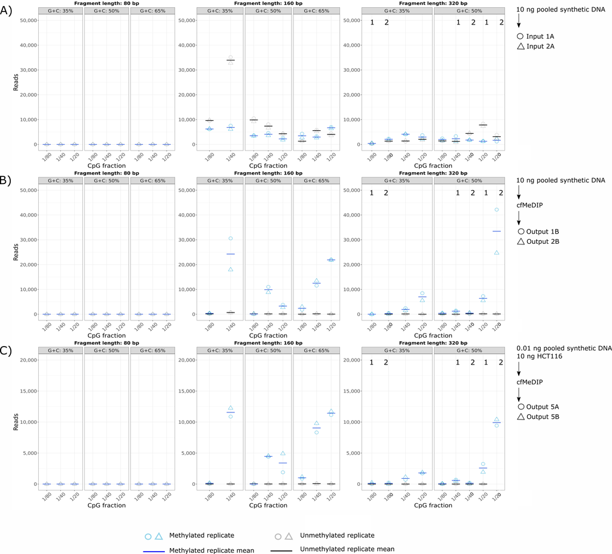

## **02_pmol_filtering_hexbin.R**

This script assess the relationship between molar amount (picomoles) and mappability scores, and standard deviation.

```r
#!/usr/bin/env Rscript

##load libraries
library(plyr)
library(dplyr)
library(ggplot2)
library(reshape2)
library(gridExtra)
library(stringr)
library(varhandle)
library(forcats)
library(purrr)
library(stringi)
library(tidyverse)
library(scales)
library(ggpubr)
library(BlandAltmanLeh)
library(cowplot)
library(GGally)
library(hexbin)
library(RColorBrewer)
library(Hmisc)

##load data
#data <- read.table("2020_intersect_fmol_mapability.bed")
#colnames(data) <- c("chr_umap","start_umap","end_umap", "map_score", "chr", "start", "end", "overlap")

##aggregate by window - mean mappability score
#data$window <- as.factor(paste0(data$chr,"_", data$start, "_", data$end))
#data_agg <- ddply(data,.(data$window, data$chr, data$start, data$end),numcolwise(mean), .progress = "text")
#colnames(data_agg) <- c("window","chr", "start", "end", "start_umap", "end_umap", "map_score", "overlap")
#print(head(data_agg))
#print(dim(data_agg))
#write.table(data_agg, header = TRUE, file = "2020_mappability_300bp_windows.csv")

##aggregate by window - min mapability score
#data$window <- as.factor(paste0(data$chr,"_", data$start, "_", data$end))
#data_agg <- ddply(data,.(data$window, data$chr, data$start, data$end),numcolwise(min), .progress = "text")
#colnames(data_agg) <- c("window","chr", "start", "end", "start_umap", "end_umap", "map_score", "overlap")
#print(head(data_agg))
#print(dim(data_agg))
#write.table(data_agg, header = TRUE, file = "2020_min_mappability_300bp_windows.csv")

mapp_windows <- read.csv("~/Annotations/2020_min_mappability_300bp_windows.csv", header = TRUE)
mapp_windows$row.names <- NULL
mapp_windows$X <- NULL

##load in pmol data
sample1 <- read.table("/cluster/projects/hoffmangroup/data_samanthawilson/2020_0.01ng_HCT116/S6547_all_pmol_hg38_intersect_adjbinned.bed", sep = "\t", header = TRUE)
colnames(sample1) <- c("chr", "start", "end", "sample1_read_count", "sample1_pmol")
sample1$window <- as.factor(paste0(sample1$chr,"_", sample1$start, "_", sample1$end))
sample1 <- sample1[-c(1:3)]

sample2 <- read.table("/cluster/projects/hoffmangroup/data_samanthawilson/2020_0.01ng_HCT116/S6548_all_pmol_hg38_intersect_adjbinned.bed", sep = "\t", header = TRUE)
colnames(sample2) <- c("chr", "start", "end", "sample2_read_count", "sample2_pmol")
sample2$window <- as.factor(paste0(sample2$chr,"_", sample2$start, "_", sample2$end))
sample2 <- sample2[-c(1:3)]

#merge all samples
conc <- merge(sample1, sample2, by = "window", all = TRUE, fill = TRUE)

print(head(conc))
print(dim(conc))

##merge with mappability data
data_all <- merge(conc, mapp_windows, by = "window")
data_all[is.na(data_all)] <- 0 #replace NA with 0 (this could be region was not methylated or was not picked up)

##take mean between samples
data_all$sample_mean <- (data_all$sample1_pmol + data_all$sample2_pmol) / 2
print(head(data_all))
print(dim(data_all))
#5103552

##ggplot2 theme
source("/cluster/home/wilsons/commonly_used_code/ggplot2_theme_bw.R")

##plot function
corr_plot <- function(means){
ggplot(means, aes(x=map_score, y= sample_mean)) +
  geom_point(color='#2980B9', size = 2) +
  geom_smooth(method=lm, se=FALSE, fullrange=TRUE, color='#2C3E50') +
  ylab("Picomole") +
  xlab("Mappability score") +
  stat_cor(method = "spearman") +
  scale_y_continuous(labels = comma)
}

##Make plot
png("2020_conc_mapp_corr.png", height = 6, width = 6, units = "in", res =300)
corr_plot(data_all)
dev.off()
#cor -0.028

###Plots with mean mappability score
##Make ggplot hexbin plot
png("2020_conc_mapp_corr_hexbin_morecounts.png", height = 6, width = 6, units = "in", res =300)
hex <- hexbin(data_all$map_score, data_all$sample_mean, 20)
   gghex <- data.frame(hcell2xy(hex), count = log(hex@count),
                        xo = hex@xcm, yo = hex@ycm)
ggplot(gghex, aes(x = x, y = y, fill = count) ) +
  geom_hex(bins = 40, stat = "identity") +
  scale_fill_continuous(type = "viridis") +
  labs(x = "Mappability score", y = "Picomoles", fill = "Log of counts") +
  scale_y_continuous(labels = comma)
dev.off()

##Looking into what the high fmol regions are
### subset the windows that have > 5000fmol
high_pmol <- subset(data_all, data_all$sample_mean > 1)
rownames(high_pmol) <- high_pmol$window
#### 3 windows above 2pmol, 5 over 1 pmol

### Are any of these regions on the ENCODE blacklist?
repeats <- read.table("~/Annotations/2020_repeatregions_mappedto300bpwindows.bed", sep = "\t", header = FALSE)
###subset to regions where there are overlaps between our windows
repeats <- subset(repeats, repeats$V9>0)
repeats <- repeats[,c(1:3)]
colnames(repeats) <- c("chr","start","end")
repeats$window <- paste0(repeats$chr,"_",repeats$start,"_",repeats$end)
repeats <- unique(repeats)
rownames(repeats) <-repeats$window

blacklist <- read.table("~/Annotations/2020_new_ENCODE_blacklist.csv", sep = "\t", header = FALSE)
colnames(blacklist) <- c("bl_chr", "bl_start", "bl_end", "chr", "start", "end", "overlap")
blacklist$window <- paste0(blacklist$chr,"_",blacklist$start,"_",blacklist$end)
blacklist <- unique(blacklist)

overlap_repetitiveregions <- high_pmol[rownames(high_pmol) %in% rownames(repeats),]
##Every single one is on the UCSC repetitive regions black list

overlap_blacklist <- high_pmol[rownames(high_pmol) %in% rownames(blacklist),]

##remove the blacklist regions and remake the hexbin plot.
rm <- repeats$window
rownames(data_all) <- data_all$window
data_noblacklist <- data_all[!rownames(data_all) %in% rm,]

rm <- blacklist$window
data_noblacklist <- data_noblacklist[!rownames(data_noblacklist) %in% rm,]
#4546731 windows

png("2020_conc_mapp_corr_hexbin_noblacklist_morecounts.png", height = 6, width = 6, units = "in", res =300)
hex <- hexbin(data_noblacklist$map_score, data_noblacklist$sample_mean, 20)
   gghex <- data.frame(hcell2xy(hex), count = log(hex@count),
                        xo = hex@xcm, yo = hex@ycm)
ggplot(gghex, aes(x = x, y = y, fill = count) ) +
  geom_hex(bins = 40, stat = "identity") +
  scale_fill_continuous(type = "viridis") +
  labs(x = "Mappability score", y = "Picomoles", fill = "Log of counts") +
  scale_y_continuous(labels = comma)
dev.off()

## Follow up on the high fmol sites not in the blacklist or  STR list
high_pmol2 <- subset(data_noblacklist, data_noblacklist$sample_mean > 0.5)
write.csv(high_pmol2, file = "2020_highpmol_noblacklist.csv")
#117 windows

###Plots with minimum mappability score
##Make ggplot hexbin plot
png("2020_conc_minmapp_corr_hexbin_morecounts.png", height = 6, width = 6, units = "in", res =300)
hex <- hexbin(data_all$map_score, data_all$sample_mean, 20)
   gghex <- data.frame(hcell2xy(hex), count = log(hex@count),
                        xo = hex@xcm, yo = hex@ycm)
ggplot(gghex, aes(x = x, y = y, fill = count) ) +
  geom_hex(bins = 40, stat = "identity") +
  scale_fill_continuous(type = "viridis") +
  labs(x = "Mappability score", y = "Femtomoles", fill = "Log of counts") +
  scale_y_continuous(labels = comma)
dev.off()

##Looking into what the high fmol regions are
### subset the windows that have > 5000fmol

high_pmol <- subset(data_all, data_all$sample_mean > 1)
rownames(high_pmol) <- high_pmol$window
#### 5 windows, 3 on chromosome 16

##remove the blacklist regions and remake the hexbin plot.
rm <- repeats$window
rownames(data_all) <- data_all$window
data_noblacklist <- data_all[!rownames(data_all) %in% rm,]

rm <- blacklist$window
data_noblacklist <- data_noblacklist[!rownames(data_noblacklist) %in% rm,]

png("2020_conc_minmapp_corr_hexbin_noblacklist_morecounts.png", height = 6, width = 6, units = "in", res =300)
hex <- hexbin(data_noblacklist$map_score, data_noblacklist$sample_mean, 20)
   gghex <- data.frame(hcell2xy(hex), count = log(hex@count),
                        xo = hex@xcm, yo = hex@ycm)
ggplot(gghex, aes(x = x, y = y, fill = count) ) +
  geom_hex(bins = 40, stat = "identity") +
  scale_fill_continuous(type = "viridis") +
  labs(x = "Mappability score", y = "Picomoles", fill = "Log of counts") +
  scale_y_continuous(labels = comma)
dev.off()

## Follow up on the high fmol sites not in the blacklist or  STR list
high_pmol2 <- subset(data_noblacklist, data_noblacklist$sample_mean > 0.5)
write.csv(high_pmol2, file = "2020_highpmol_minmappability_noblacklist.csv")
# 117 windows, most have high map scores

##Hexbin plot with standard deviation
data_noblacklist$sd <- apply(data_noblacklist[, c("sample1_pmol","sample2_pmol")],1,sd)

png("2020_pmol_sd_corr.png", height = 6, width = 6, units = "in", res =300)
hex <- hexbin(data_noblacklist$sd, data_noblacklist$sample_mean, 20)
   gghex <- data.frame(hcell2xy(hex), count = log(hex@count),
                        xo = hex@xcm, yo = hex@ycm)
ggplot(gghex, aes(x = x, y = y, fill = count) ) +
  geom_hex(bins = 40, stat = "identity") +
  scale_fill_continuous(type = "viridis") +
  labs(x = "Standard deviation", y = "Picomoles", fill = "Log of counts") +
  scale_y_continuous(labels = comma)
dev.off()

rm <- subset(data_noblacklist, data_noblacklist$sd > 0.05 | data_noblacklist$map_score < 0.5)
data_filtered <- data_noblacklist[!rownames(data_noblacklist) %in% rownames(rm),]
#4446375 windows

##Set up colour palette
library(RColorBrewer)
pal <- brewer.pal(n = 8, name = "Blues")[3:8]

png("2020_pmol_sd_filtered_pubplt.png", height = 6, width = 6, units = "in", res =300)
hex <- hexbin(data_filtered$sd, data_filtered$sample_mean, 20)
   gghex <- data.frame(hcell2xy(hex), count = log(hex@count),
                        xo = hex@xcm, yo = hex@ycm)
pmol_sd <- ggplot(gghex, aes(x = x, y = y, fill = count)) +
  geom_hex(bins = 40, stat = "identity") +
  scale_fill_gradientn(colors = pal, breaks = c(0, 5, 10, 15,20), labels = c("0" , "5", "10", "15", "20")) +
  labs(x = "Standard deviation", y = "Picomoles", fill = "Reads") +
  scale_y_continuous(labels = comma)
pmol_sd
dev.off()


##Redo hebin mappability without the sd
png("2020_pmol_mapp_filtered_pubplt.png", height = 6, width = 6, units = "in", res =300)
hex <- hexbin(data_filtered$map_score, data_filtered$sample_mean, 20)
   gghex <- data.frame(hcell2xy(hex), count = log(hex@count),
                        xo = hex@xcm, yo = hex@ycm)
pmol_mapp <- ggplot(gghex, aes(x = x, y = y, fill = count) ) +
  geom_hex(bins = 40, stat = "identity") +
  scale_fill_gradientn(colors = pal,  breaks = c(0, 5, 10, 15,20), labels = c("0" , "5", "10", "15", "20")) +
  labs(x = "Mappability score", y = "Picomoles", fill = "Reads") +
  scale_y_continuous(labels = comma)
pmol_mapp
dev.off()

##Extracting legend, so all plots are same size in the grid.arrange()
#https://github.com/hadley/ggplot2/wiki/Share-a-legend-between-two-ggplot2-graphs
g_legend <- function(a_gplot) {
  tmp <- ggplot_gtable(ggplot_build(a_gplot))
  leg <- which(sapply(tmp$grobs, function(x) x$name) == "guide-box")
  legend <- tmp$grobs[[leg]]
  return(legend)
  }

##Arranging plots together
png("2020_pmol_sd_mapp_corr_pubplt.png", height =6, width = 12, units = "in", res =300)
mylegend <- g_legend(pmol_sd)
grid.arrange(arrangeGrob(pmol_sd + theme(legend.position = "none")),
        arrangeGrob(pmol_mapp + theme(legend.position = "none")), nrow = 1, mylegend)
dev.off()

##What are the highest pmol predictions
high_pmol <- data_filtered[data_filtered$sample_mean > 0.25 & data_filtered$map_score < 1 | data_filtered$sample_mean > 0.7,] #11 windows
write.csv(high_pmol, file = "2020_highpmol_minmappability_noblacklist.csv")
```

The output of this script is figure 3 in the manuscript:

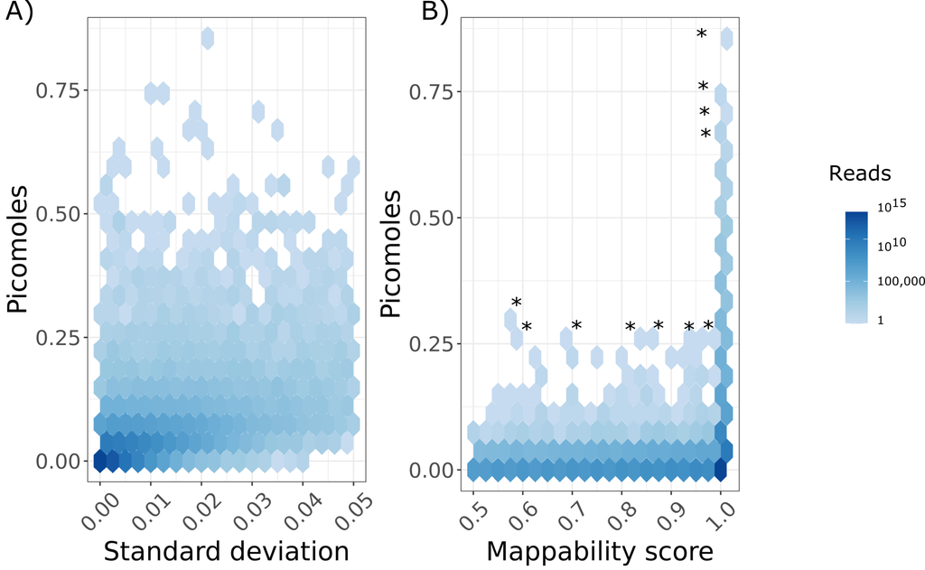

Figure 3

## **03_mval_pmol_corr.R**

This script correlated M-values from the Illumina EPIC array the our calculated molar amount (picomoles) and to raw read counts.

```r
#!/usr/bin/env Rscript

#Load libraries
library(plyr)
library(dplyr)
library(ggplot2)
library(reshape2)
library(gridExtra)
library(stringr)
library(varhandle)
library(forcats)
library(purrr)
library(stringi)
library(tidyverse)
#library(lumi)
library(scales)
library(ggpubr)

#Load data

##Predicted concentration metrics
##load in pmol data
sample1 <- read.table("/cluster/projects/hoffmangroup/data_samanthawilson/2020_0.01ng_HCT116/S6547_all_pmol_hg38_intersect_adjbinned.bed", sep = "\t", header = TRUE)
colnames(sample1) <- c("chr", "start", "end", "sample1_read_count", "sample1_pmol")
sample1$window <- as.factor(paste0(sample1$chr,"_", sample1$start, "_", sample1$end))
sample1 <- sample1[-c(1:3)]

sample2 <- read.table("/cluster/projects/hoffmangroup/data_samanthawilson/2020_0.01ng_HCT116/S6548_all_pmol_hg38_intersect_adjbinned.bed", sep = "\t", header = TRUE)
colnames(sample2) <- c("chr", "start", "end", "sample2_read_count", "sample2_pmol")
sample2$window <- as.factor(paste0(sample2$chr,"_", sample2$start, "_", sample2$end))
sample2 <- sample2[-c(1:3)]

#merge all samples
conc <- merge(sample1, sample2, by = "window", all = TRUE, fill = TRUE)
rownames(conc) <- conc$window

print(head(conc))
print(dim(conc))

epic <- read.delim("2019_HCT116_sesame_betas_windows.csv", sep = ",", header = TRUE)
epic$X <- NULL
epic$start <- NULL
epic$end <- NULL
epic$probepos <- NULL
colnames(epic) <- c("window","Sample1","Sample2","Sample3")

##Remove repetitive elements- simple repeats only
repeats <- read.table("~/Annotations/2020_repeatregions_mappedto300bpwindows.bed", sep = "\t", header = FALSE)
###subset to regions where there are overlaps between our windows
repeats <- subset(repeats, repeats$V9>0)
repeats <- repeats[,c(1:3)]
colnames(repeats) <- c("chr","start","end")
repeats$window <- paste0(repeats$chr,"_",repeats$start,"_",repeats$end)
repeats <- unique(repeats)
rownames(repeats) <-repeats$window

##remove repetitive regions from the data
conc <- conc[!rownames(conc) %in% rownames(repeats),]

##remove blacklist regions
blacklist <- read.table("~/Annotations/2020_new_ENCODE_blacklist.csv", sep = "\t", header = FALSE)
colnames(blacklist) <- c("bl_chr", "bl_start", "bl_end", "chr", "start", "end", "overlap")
blacklist$window <- paste0(blacklist$chr,"_",blacklist$start,"_",blacklist$end)
blacklist <- unique(blacklist)

##remove blacklist regions
conc <-conc[!rownames(conc) %in% blacklist$window,]

## remove low mappability regions (mappability score<0.5)
mappability <- read.csv("~/Annotations/2020_min_mappability_300bp_windows.csv", header = TRUE)
mappability$X <- NULL

mappability_0.5 <- subset(mappability, mappability$map_score<0.5)

conc <- conc[!rownames(conc) %in% mappability_0.5$window,]
#4456768 windows

#subset out samples with sd >0.05
conc$sd <- apply(conc[, c("sample1_pmol","sample2_pmol")],1,sd)

rm <- subset(conc, conc$sd > 0.05)
conc <- conc[!rownames(conc) %in% rownames(rm),]
#4455866

##subset conc and epic to only those windows present in both
windows_of_interest <- epic$window

conc_subset <- subset(conc, rownames(conc) %in% windows_of_interest)

rownames(epic) <- epic$window
epic_subset <- subset(epic, rownames(epic) %in% rownames(conc))

##mean the samples
conc_means <- data.frame(ID=conc_subset$window, Means=rowMeans(conc_subset[,c("sample1_pmol","sample2_pmol")]))
epic_means <- data.frame(ID=epic_subset$window, Means=rowMeans(epic_subset[,c("Sample1","Sample2","Sample3")]))

means <- merge(conc_means, epic_means, by = "ID")
colnames(means) <- c("window","conc","epic")

##changes betas to m-values
means$epic_m <- log2(means$epic/(1-means$epic))

##Correlation calculation
cor.test(means$conc, means$epic_m, method = 'spearman')
##0.1475338

conc[is.na(conc)] <- 0

##ggplot2 theme
source("/cluster/home/wilsons/commonly_used_code/ggplot2_theme_bw.R")

##plot function
corr_plot <- function(means){
ggplot(means, aes(x= epic_m, y= conc)) +
  geom_point(color='#2980B9', size = 2) +
  geom_smooth(method=lm, se=FALSE, fullrange=TRUE, color='#2C3E50') +
  ylab("Picomoles") +
  xlab("DNA methylation (M-value)") +
  #stat_cor(method = "spearman", aes(label = paste(..r.label.., expression(paste("p < 2.2x",10^-16)), sep = "*`,`~")), digits = 2, r.digits = 2, r.accuracy = 0.01)+
  scale_y_continuous(labels = comma)
}

##Plot
png("2020_conc_epic_sesame_mapp_corr.png", height = 6, width = 6, units = "in", res =300)
all_pts <- corr_plot(means)
all_pts
dev.off()


##Correlate bins with >3 CpG represented on array
##Let's correlate those this more than 3 cpg present in window
high_cpg <- read.csv("2020_HCT116_sesame_betas_windows_highcpg3.csv", row.names = 1, header = TRUE)
#50053 windows

high_cpg$CpG_beg <- NULL
high_cpg$CpG_end <- NULL
colnames(high_cpg) <- c("window","Sample1","Sample2","Sample3")

##subset conc and epic to only those windows present in both
windows_of_interest <- high_cpg$window

rownames(conc) <- conc$window
conc_subset <- subset(conc, rownames(conc) %in% windows_of_interest)

rownames(high_cpg) <- high_cpg$window
high_subset <- subset(high_cpg, rownames(high_cpg) %in% rownames(conc))

##mean the samples
conc_high_means <- data.frame(ID=conc_subset$window, Means=rowMeans(conc_subset[,c("sample1_pmol","sample2_pmol")]))
epic_high_means <- data.frame(ID=high_subset$window, Means=rowMeans(high_subset[,c("Sample1","Sample2","Sample3")]))

high_means <- merge(conc_high_means, epic_high_means, by = "ID")
colnames(high_means) <- c("window","conc","epic")
high_means$epic_m <- log2(high_means$epic/(1-high_means$epic))

##Correlation calculation
cor.test(high_means$conc, high_means$epic_m, method = 'spearman')
##0.6239577  - with 3 CpG and 50053 windows

##Full plot
png("2020_conc_epicsesame_corr_mapp_morethan3CpG.png", height = 6, width = 6, units = "in", res =300)
corr_more3cpg <- corr_plot(high_means) +
                 scale_x_continuous(limits = c(-8, 8), breaks = c(-6, -4, -2, 0, 2, 4, 6)) +
                 scale_y_continuous(limits = c(0,10), breaks = c(0, 2, 4, 6, 8, 10))
corr_more3cpg
dev.off()
```

```r
##Let's correlate those this more than 5 cpg present in window
high_cpg <- read.csv("2020_HCT116_sesame_betas_windows_highcpg5.csv", row.names = 1, header = TRUE)
#12602 windows

high_cpg$CpG_beg <- NULL
high_cpg$CpG_end <- NULL
colnames(high_cpg) <- c("window","Sample1","Sample2","Sample3")

##subset conc and epic to only those windows present in both
windows_of_interest <- high_cpg$window

rownames(conc) <- conc$window
conc_subset <- subset(conc, rownames(conc) %in% windows_of_interest)

rownames(high_cpg) <- high_cpg$window
high_subset <- subset(high_cpg, rownames(high_cpg) %in% rownames(conc))

##mean the samples
conc_high_means <- data.frame(ID=conc_subset$window, Means=rowMeans(conc_subset[,c("sample1_pmol","sample2_pmol")]))
epic_high_means <- data.frame(ID=high_subset$window, Means=rowMeans(high_subset[,c("Sample1","Sample2","Sample3")]))

high_means <- merge(conc_high_means, epic_high_means, by = "ID")
colnames(high_means) <- c("window","conc","epic")
high_means$epic_m <- log2(high_means$epic/(1-high_means$epic))

##Correlation calculation
cor.test(high_means$conc, high_means$epic_m, method = 'spearman')
##0.8007208    - with more than 5 CpG and 12602 windows

##Full plot
png("2020_conc_epicsesame_corr_mapp_morethan5CpG.png", height = 6, width = 6, units = "in", res =300)
corr_more5cpg <- corr_plot(high_means) +
                 scale_x_continuous(limits = c(-8, 8), breaks = c(-6, -4, -2, 0, 2, 4, 6)) +
scale_y_continuous(limits = c(0,10), breaks = c(0, 2, 4, 6, 8, 10))
corr_more5cpg
dev.off()

### 7 CpG
high_cpg <- read.csv("2020_HCT116_sesame_betas_windows_highcpg7.csv", row.names = 1, header = TRUE)
#3567 windows

high_cpg$CpG_beg <- NULL
high_cpg$CpG_end <- NULL
colnames(high_cpg) <- c("window","Sample1","Sample2","Sample3")

##subset conc and epic to only those windows present in both
windows_of_interest <- high_cpg$window

rownames(conc) <- conc$window
conc_subset <- subset(conc, rownames(conc) %in% windows_of_interest)

rownames(high_cpg) <- high_cpg$window
high_subset <- subset(high_cpg, rownames(high_cpg) %in% rownames(conc))

##mean the samples
conc_high_means <- data.frame(ID=conc_subset$window, Means=rowMeans(conc_subset[,c("sample1_pmol","sample2_pmol")]))
epic_high_means <- data.frame(ID=high_subset$window, Means=rowMeans(high_subset[,c("Sample1","Sample2","Sample3")]))

high_means <- merge(conc_high_means, epic_high_means, by = "ID")
colnames(high_means) <- c("window","conc","epic")
high_means$epic_m <- log2(high_means$epic/(1-high_means$epic))

##Correlation calculation
cor.test(high_means$conc, high_means$epic_m, method = 'spearman')
##0.8206853   - with more than 7 CpG and 3567 windows

##Full plot
png("2020_conc_epicsesame_corr_mapp_morethan7CpG.png", height = 6, width = 6, units = "in", res =300)
corr_more7cpg <- corr_plot(high_means) +
  scale_x_continuous(limits = c(-8, 8), breaks = c(-6, -4, -2, 0, 2, 4, 6)) +
scale_y_continuous(limits = c(0,10), breaks = c(0, 2, 4, 6, 8, 10))
corr_more7cpg
dev.off()

###10 CpG
high_cpg <- read.csv("2020_HCT116_sesame_betas_windows_highcpg10.csv", row.names = 1, header = TRUE)
#294 windows

high_cpg$CpG_beg <- NULL
high_cpg$CpG_end <- NULL
colnames(high_cpg) <- c("window","Sample1","Sample2","Sample3")

##subset conc and epic to only those windows present in both
windows_of_interest <- high_cpg$window

rownames(conc) <- conc$window
conc_subset <- subset(conc, rownames(conc) %in% windows_of_interest)

rownames(high_cpg) <- high_cpg$window
high_subset <- subset(high_cpg, rownames(high_cpg) %in% rownames(conc))

##mean the samples
conc_high_means <- data.frame(ID=conc_subset$window, Means=rowMeans(conc_subset[,c("sample1_pmol","sample2_pmol")]))
epic_high_means <- data.frame(ID=high_subset$window, Means=rowMeans(high_subset[,c("Sample1","Sample2","Sample3")]))

high_means <- merge(conc_high_means, epic_high_means, by = "ID")
colnames(high_means) <- c("window","conc","epic")
high_means$epic_m <- log2(high_means$epic/(1-high_means$epic))

##Correlation calculation
cor.test(high_means$conc, high_means$epic_m, method = 'spearman')
##0.8703139    - with more than 10 CpG and 294 windows

##Full plot
png("2020_conc_epicsesame_corr_mapp_morethan10CpG.png", height = 6, width = 6, units = "in", res =300)
corr_more10cpg <- corr_plot(high_means) +
  scale_x_continuous(limits = c(-8, 8), breaks = c(-6, -4, -2, 0, 2, 4, 6)) +
scale_y_continuous(limits = c(0,10), breaks = c(0, 2, 4, 6, 8, 10))
corr_more10cpg
dev.off()

#### Correlation of read counts to M-values
##mean the samples
rc_means <- data.frame(ID=conc$window, Means=rowMeans(conc[,c("sample1_read_count","sample2_read_count")]))
epic_means <- data.frame(ID=epic_subset$window, Means=rowMeans(epic_subset[,c("Sample1","Sample2","Sample3")]))

means <- merge(rc_means, epic_means, by = "ID")
colnames(means) <- c("window","readcount","epic")

##changes betas to m-values
means$epic_m <- log2(means$epic/(1-means$epic))
print(head(means))

###Change corr_plot function so that y is readcounts
corr_plot <- function(data){
ggplot(data, aes(x= epic_m, y= readcounts)) +
  geom_point(color='#2980B9', size = 2) +
  geom_smooth(method=lm, se=FALSE, fullrange=TRUE, color='#2C3E50') +
  ylab("Reads") +
  xlab("DNA methylation (M-value)") +
  #stat_cor(method = "spearman", aes(label = paste(..r.label.., expression(paste("p < 2.2x",10^-16)), sep = "*`,`~")), digits = 2, r.digits = 2) +
  scale_y_continuous(labels = comma)
}


##Correlate bins with >3 CpG represented on array
##Let's correlate those this more than 3 cpg present in window
high_cpg <- read.csv("2020_HCT116_sesame_betas_windows_highcpg3.csv", row.names = 1, header = TRUE)

high_cpg$CpG_beg <- NULL
high_cpg$CpG_end <- NULL
colnames(high_cpg) <- c("window","Sample1","Sample2","Sample3")

##subset conc and epic to only those windows present in both
windows_of_interest <- high_cpg$window

conc_subset <- subset(conc, rownames(conc) %in% windows_of_interest)

rownames(high_cpg) <- high_cpg$window
high_subset <- subset(high_cpg, rownames(high_cpg) %in% rownames(conc_subset))
```

```r
##mean the samples
rc_high_means <- data.frame(ID=conc_subset$window, Means=rowMeans(conc_subset[,c("sample1_read_count","sample2_read_count")]))
epic_high_means <- data.frame(ID=high_subset$window, Means=rowMeans(high_subset[,c("Sample1","Sample2","Sample3")]))

high_means <- merge(rc_high_means, epic_high_means, by = "ID")
colnames(high_means) <- c("window","readcounts","epic")
high_means$epic_m <- log2(high_means$epic/(1-high_means$epic))

##Correlation calculation
cor.test(high_means$readcounts, high_means$epic_m, method = 'spearman')
##0.6203779

##Full plot
png("2020_readcounts_epicsesame_corr_mapp_morethan3CpG.png", height = 6, width = 6, units = "in", res =300)
corr_more3cpg_rc <- corr_plot(high_means) +
    scale_x_continuous(limits = c(-8, 8), breaks = c(-6, -4, -2, 0, 2, 4, 6)) +
        scale_y_continuous(limits = c(0,500), breaks = c(0, 100, 200, 300, 400, 500))
corr_more3cpg_rc
dev.off()

##Let's correlate those this more than 5 cpg present in window
high_cpg <- read.csv("2020_HCT116_sesame_betas_windows_highcpg5.csv", row.names = 1, header = TRUE)

high_cpg$CpG_beg <- NULL
high_cpg$CpG_end <- NULL
colnames(high_cpg) <- c("window","Sample1","Sample2","Sample3")

##subset conc and epic to only those windows present in both
windows_of_interest <- high_cpg$window

conc_subset <- subset(conc, rownames(conc) %in% windows_of_interest)

rownames(high_cpg) <- high_cpg$window
high_subset <- subset(high_cpg, rownames(high_cpg) %in% rownames(conc_subset))

##mean the samples
rc_high_means <- data.frame(ID=conc_subset$window, Means=rowMeans(conc_subset[,c("sample1_read_count","sample2_read_count")]))
epic_high_means <- data.frame(ID=high_subset$window, Means=rowMeans(high_subset[,c("Sample1","Sample2","Sample3")]))

high_means <- merge(rc_high_means, epic_high_means, by = "ID")
colnames(high_means) <- c("window","readcounts","epic")
high_means$epic_m <- log2(high_means$epic/(1-high_means$epic))

##Correlation calculation
cor.test(high_means$readcounts, high_means$epic_m, method = 'spearman')
## 0.8138254

##Full plot
png("2020_readcounts_epicsesame_corr_mapp_morethan5CpG.png", height = 6, width = 6, units = "in", res =300)
corr_more5cpg_rc <- corr_plot(high_means) +
        scale_x_continuous(limits = c(-8, 8), breaks = c(-6, -4, -2, 0, 2, 4, 6)) +
        scale_y_continuous(limits = c(0,500), breaks = c(0, 100, 200, 300, 400, 500))
corr_more5cpg_rc
dev.off()

###Correlate read counts with >7cpg
high_cpg <- read.csv("2020_HCT116_sesame_betas_windows_highcpg7.csv", row.names = 1, header = TRUE)

high_cpg$CpG_beg <- NULL
high_cpg$CpG_end <- NULL
colnames(high_cpg) <- c("window","Sample1","Sample2","Sample3")

##subset conc and epic to only those windows present in both
windows_of_interest <- high_cpg$window

conc_subset <- subset(conc, rownames(conc) %in% windows_of_interest)

rownames(high_cpg) <- high_cpg$window
high_subset <- subset(high_cpg, rownames(high_cpg) %in% rownames(conc_subset))

##mean the samples
rc_high_means <- data.frame(ID=conc_subset$window, Means=rowMeans(conc_subset[,c("sample1_read_count","sample2_read_count")]))
epic_high_means <- data.frame(ID=high_subset$window, Means=rowMeans(high_subset[,c("Sample1","Sample2","Sample3")]))

high_means <- merge(rc_high_means, epic_high_means, by = "ID")
colnames(high_means) <- c("window","readcounts","epic")
high_means$epic_m <- log2(high_means$epic/(1-high_means$epic))

##Correlation calculation
cor.test(high_means$readcounts, high_means$epic_m, method = 'spearman')
##0.8461799

##Full plot
png("2020_readcounts_epicsesame_corr_mapp_morethan7CpG.png", height = 6, width = 6, units = "in", res =300)
corr_more7cpg_rc <- corr_plot(high_means) +
        scale_x_continuous(limits = c(-8, 8), breaks = c(-6, -4, -2, 0, 2, 4, 6)) +
scale_y_continuous(limits = c(0,500), breaks = c(0, 100, 200, 300, 400, 500))
corr_more7cpg_rc
dev.off()

###>10 cpgs
high_cpg <- read.csv("2020_HCT116_sesame_betas_windows_highcpg10.csv", row.names = 1, header = TRUE)

high_cpg$CpG_beg <- NULL
high_cpg$CpG_end <- NULL
colnames(high_cpg) <- c("window","Sample1","Sample2","Sample3")

##subset conc and epic to only those windows present in both
windows_of_interest <- high_cpg$window

conc_subset <- subset(conc, rownames(conc) %in% windows_of_interest)

rownames(high_cpg) <- high_cpg$window
high_subset <- subset(high_cpg, rownames(high_cpg) %in% rownames(conc_subset))

##mean the samples
rc_high_means <- data.frame(ID=conc_subset$window, Means=rowMeans(conc_subset[,c("sample1_read_count","sample2_read_count")]))
epic_high_means <- data.frame(ID=high_subset$window, Means=rowMeans(high_subset[,c("Sample1","Sample2","Sample3")]))

high_means <- merge(rc_high_means, epic_high_means, by = "ID")
colnames(high_means) <- c("window","readcounts","epic")
high_means$epic_m <- log2(high_means$epic/(1-high_means$epic))

##Correlation calculation
cor.test(high_means$readcounts, high_means$epic_m, method = 'spearman')
##0.877321

##Full plot
png("2020_readcounts_epicsesame_corr_mapp_morethan10CpG.png", height = 6, width = 6, units = "in", res =300)
corr_more10cpg_rc <- corr_plot(high_means) +
        scale_x_continuous(limits = c(-8, 8), breaks = c(-6, -4, -2, 0, 2, 4, 6)) +
scale_y_continuous(limits = c(0,500), breaks = c(0, 100, 200, 300, 400, 500))
corr_more10cpg_rc
dev.off()

##Read count and pmol
##y axis cut to 500 in read counts, this does cut some of the points off, but looks cleaners. The correlations reported are for all points.
png("2020_pmol_readcounts_sesamemval_corr_mapp_allplts.png", height = 12, width = 8, units = "in", res = 300)
all_rc_corr_plot <- grid.arrange(arrangeGrob(corr_more3cpg + scale_y_continuous(limits=c(0,0.5)) + theme(axis.title.x = element_blank()), top = grid::textGrob("≥ 3 CpG/300 bp window (N = 34,735 windows)", x = 0.6, hjust =0)),
                arrangeGrob(corr_more3cpg_rc + scale_y_continuous(limits=c(0,500)) + theme(axis.title.x = element_blank()), top = ""),
                            arrangeGrob(corr_more5cpg + scale_y_continuous(limits=c(0,0.5)) + theme(axis.title.x = element_blank()), top = grid::textGrob("≥ 5 CpG/300 bp window (N = 7,203 windows)", x = 0.6, hjust = 0)),
                arrangeGrob(corr_more5cpg_rc + scale_y_continuous(limits=c(0,500)) + theme(axis.title.x = element_blank()), top = ""),
                            arrangeGrob(corr_more7cpg + scale_y_continuous(limits=c(0,0.5)) + theme(axis.title.x = element_blank()), top = grid::textGrob("≥ 7 CpG/300 bp window (N = 1,898 windows)", x = 0.6, hjust = 0)),
                arrangeGrob(corr_more7cpg_rc + scale_y_continuous(limits=c(0,500)) + theme(axis.title.x = element_blank()), top =""),
                arrangeGrob(corr_more10cpg + scale_y_continuous(limits=c(0,0.5)) + theme(axis.title.x = element_blank()), top = grid::textGrob("≥ 10 CpG/300 bp window (N = 147 windows)", x =0.6, hjust = 0)),
                            arrangeGrob(corr_more10cpg_rc + theme(axis.title.x = element_blank()), top = ""), ncol =2)
```

```r
annotate_figure(all_rc_corr_plot,
               bottom = text_grob("DNA methylation (M-value)", color = "black",
                                   size = 16))
dev.off()
```

The output of this script is figure 4 in the manuscript:

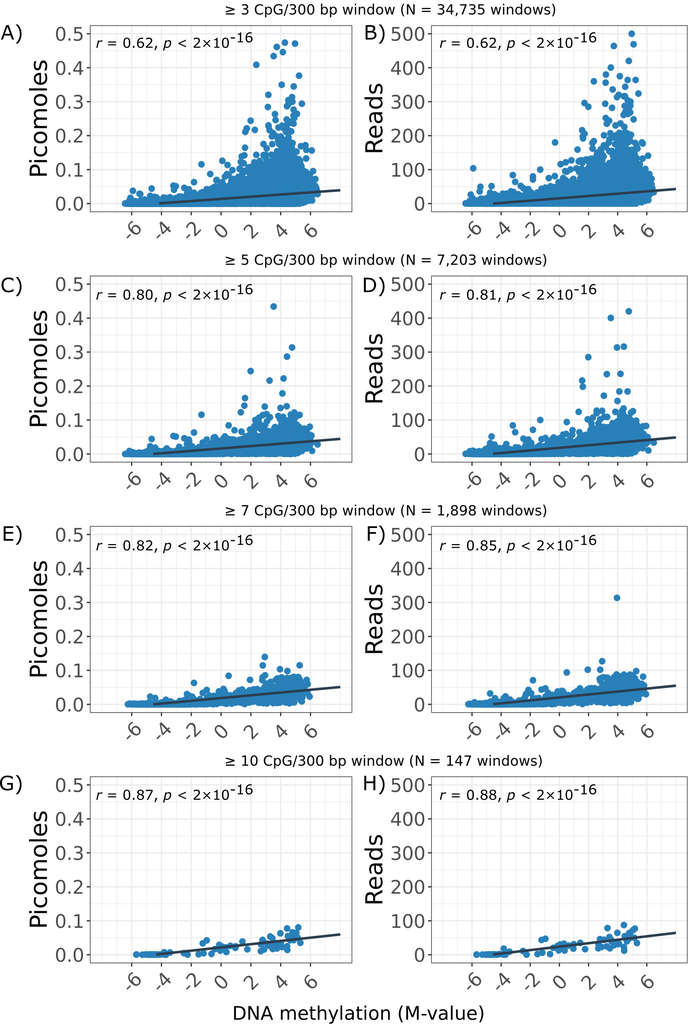

Figure 4

## **04_PrincipalComponents_Batches.R**

The scripts normalizes raw read count data with QSEA.

The script subsequently performs principal component analyis on raw read counts, QSEA normalized counts, molar amount (picomoles), and molar amount (picomoles) filtered to our suggested sites. Each principal component is correlated to known variables within the data.

```r
#!/usr/bin/env Rscript

##Load needed packages

library("qsea")
library("BSgenome")
library("BSgenome.Hsapiens.UCSC.hg38")
BSgenome= "BSgenome.Hsapiens.UCSC.hg38"
library(ggplot2)
library(gridExtra)
library(ggpubr)
library(scales)
library(stringr)
library(cowplot)
library(reshape2)
library(plyr)
library(compute.es)
library(grid)
library(tidyvers)

###Heat-scree plots are adapted from:
#### De Souza, Rebecca AG, et al. "DNA methylation profiling in human Huntington's disease brain." Human molecular genetics 25.10 (2016): 2013-2030.

##ggplot2 theme
source("/cluster/home/wilsons/commonly_used_code/ggplot2_theme_bw.R")

#Bam files for this project
PATH_PREFIX_B1 <- "/cluster/projects/hoffmangroup/data_samanthawilson/2020_Batch1_RS/"
BamsList_B1 <- list.files(path=PATH_PREFIX_B1, pattern = "filtered_human.*dedup.bam")
bamFile_B1 <- data.frame(paste0(PATH_PREFIX_B1,BamsList_B1))
colnames(bamFile_B1) <- "file_name"

PATH_PREFIX_B2 <- "/cluster/projects/hoffmangroup/data_samanthawilson/2020_Batch2_JB/"
BamsList_B2 <- list.files(path=PATH_PREFIX_B2, pattern = "filtered_human.*dedup.bam")
bamFile_B2 <- data.frame(paste0(PATH_PREFIX_B2,BamsList_B2))
colnames(bamFile_B2) <- "file_name"

PATH_PREFIX_B3 <- "/cluster/projects/hoffmangroup/data_samanthawilson/2020_Batch3_DT/"
BamsList_B3 <- list.files(path=PATH_PREFIX_B3, pattern = "filtered_human.*dedup.bam")
bamFile_B3 <- data.frame(paste0(PATH_PREFIX_B3,BamsList_B3))
colnames(bamFile_B3) <- "file_name"

bamFile <- rbind(bamFile_B1, bamFile_B2, bamFile_B3)

#Create Qsea set for each sample and bind together in a list
sample_table = data.frame(sample_name = paste0("sample_", 1:15), file_name = bamFile$file_name, group = c(rep("B1",5), rep("B2", 5), rep ("B3", 5)), stringsAsFactors = FALSE)

#Defining parameters again
BSgenome="BSgenome.Hsapiens.UCSC.hg38"
ws=300
chr.select=paste0("chr",1:22)

#Create Qsea set for each sample, this will be combined with the other sample MEDIPS set into a list
qseaSet = createQseaSet(sampleTable = sample_table, BSgenome = BSgenome, window_size = ws, chr.select = chr.select)
qseaSet = addCoverage(qseaSet, uniquePos = TRUE, paired = TRUE)
qseaSet = addPatternDensity(qseaSet, "CG", name = "CpG", fragment_length = 300)
qseaSet=addLibraryFactors(qseaSet)
qseaSet = addOffset(qseaSet, enrichmentPattern = "CpG")

str(qseaSet)#Check that SetCreated.list is infact a list of N (number of samples in data set) MEDIPS sets

#Specify the shortened sample names here
save(qseaSet, file = "2020_allbatches_QseaSets.RData")#save the MEDIPS sets

###Load in the pmol data and merge together
###Batch 1
S1_B1 <- read.table("/cluster/projects/hoffmangroup/data_samanthawilson/2020_Batch1_RS/filtered_human.aligned.unalignedtospike.trimmed.6654_S1_L002_R1_001.fastq.1unalignedtospike.trimmed.6654_S1_L002_R1_001.fastq.2_sorted_dedup_sort_cut_CG_all_pmol_hg38_intersect_adjbinned.bed", header =T)
colnames(S1_B1) <- c("chr", "start", "end", "S1B1_read_count", "S1B1_pmol")
S1_B1$window <- paste0(S1_B1$chr,"_",S1_B1$start,"_",S1_B1$end)
S1_B1 <- S1_B1[-c(1:3)]
S1_B1 <- S1_B1 %>%  group_by(window) %>% summarise_if(is.numeric, sum)

S2_B1 <- read.table("/cluster/projects/hoffmangroup/data_samanthawilson/2020_Batch1_RS/filtered_human.aligned.unalignedtospike.trimmed.6655_S2_L002_R1_001.fastq.1unalignedtospike.trimmed.6655_S2_L002_R1_001.fastq.2_sorted_dedup_sort_cut_CG_all_pmol_hg38_intersect_adjbinned.bed", header =T)
colnames(S2_B1) <- c("chr", "start", "end", "S2B1_read_count", "S2B1_pmol")
S2_B1$window <- paste0(S2_B1$chr,"_",S2_B1$start,"_",S2_B1$end)
S2_B1 <- S2_B1[-c(1:3)]
S2_B1 <- S2_B1 %>%  group_by(window) %>% summarise_if(is.numeric, sum)

S3_B1 <- read.table("/cluster/projects/hoffmangroup/data_samanthawilson/2020_Batch1_RS/filtered_human.aligned.unalignedtospike.trimmed.6656_S3_L002_R1_001.fastq.1unalignedtospike.trimmed.6656_S3_L002_R1_001.fastq.2_sorted_dedup_sort_cut_CG_all_pmol_hg38_intersect_adjbinned.bed", header =T)
colnames(S3_B1) <- c("chr", "start", "end", "S3B1_read_count", "S3B1_pmol")
S3_B1$window <- paste0(S3_B1$chr,"_",S3_B1$start,"_",S3_B1$end)
S3_B1 <- S3_B1[-c(1:3)]
S3_B1 <- S3_B1 %>%  group_by(window) %>% summarise_if(is.numeric, sum)

S4_B1 <- read.table("/cluster/projects/hoffmangroup/data_samanthawilson/2020_Batch1_RS/filtered_human.aligned.unalignedtospike.trimmed.6657_S4_L002_R1_001.fastq.1unalignedtospike.trimmed.6657_S4_L002_R1_001.fastq.2_sorted_dedup_sort_cut_CG_all_pmol_hg38_intersect_adjbinned.bed", header =T)
colnames(S4_B1) <- c("chr", "start", "end", "S4B1_read_count", "S4B1_pmol")
S4_B1$window <- paste0(S4_B1$chr,"_",S4_B1$start,"_",S4_B1$end)
S4_B1 <- S4_B1[-c(1:3)]
S4_B1 <- S4_B1 %>%  group_by(window) %>% summarise_if(is.numeric, sum)

S5_B1 <- read.table("/cluster/projects/hoffmangroup/data_samanthawilson/2020_Batch1_RS/filtered_human.aligned.unalignedtospike.trimmed.6658_S5_L002_R1_001.fastq.1unalignedtospike.trimmed.6658_S5_L002_R1_001.fastq.2_sorted_dedup_sort_cut_CG_all_pmol_hg38_intersect_adjbinned.bed", header =T)
colnames(S5_B1) <- c("chr", "start", "end", "S5B1_read_count", "S5B1_pmol")
S5_B1$window <- paste0(S5_B1$chr,"_",S5_B1$start,"_",S5_B1$end)
S5_B1 <- S5_B1[-c(1:3)]
S5_B1 <- S5_B1 %>%  group_by(window) %>% summarise_if(is.numeric, sum)

#merge samples together
batch1 <- merge(S1_B1, S2_B1, by = "window", all = TRUE, fill = TRUE)
batch1 <- merge(batch1, S3_B1, by = "window", all = TRUE, fill = TRUE)
batch1 <- merge(batch1, S4_B1,  by = "window", all = TRUE, fill = TRUE)
batch1 <- merge(batch1, S5_B1, by = "window", all = TRUE, fill = TRUE)

###Batch2
S1_B2 <- read.table("/cluster/projects/hoffmangroup/data_samanthawilson/2020_Batch2_JB/filtered_human.aligned.unalignedtospike.trimmed.JB_A29_S11_L001_R1_001.fastq.1unalignedtospike.trimmed.JB_A29_S11_L001_R1_001.fastq.2_sorted_dedup_sort_cut_CG_all_pmol_hg38_intersect_adjbinned.bed", header =T)
colnames(S1_B2) <- c("chr", "start", "end", "S1B2_read_count", "S1B2_pmol")
S1_B2$window <- paste0(S1_B2$chr,"_",S1_B2$start,"_",S1_B2$end)
S1_B2 <- S1_B2[-c(1:3)]
S1_B2 <- S1_B2 %>%  group_by(window) %>% summarise_if(is.numeric, sum)
```

```r
S2_B2 <- read.table("/cluster/projects/hoffmangroup/data_samanthawilson/2020_Batch2_JB/filtered_human.aligned.unalignedtospike.trimmed.JB_A35_S12_L001_R1_001.fastq.1unalignedtospike.trimmed.JB_A35_S12_L001_R1_001.fastq.2_sorted_dedup_sort_cut_CG_all_pmol_hg38_intersect_adjbinned.bed", header =T)
colnames(S2_B2) <- c("chr", "start", "end", "S2B2_read_count", "S2B2_pmol")
S2_B2$window <- paste0(S2_B2$chr,"_",S2_B2$start,"_",S2_B2$end)
S2_B2 <- S2_B2[-c(1:3)]
S2_B2 <- S2_B2 %>%  group_by(window) %>% summarise_if(is.numeric, sum)

S3_B2 <- read.table("/cluster/projects/hoffmangroup/data_samanthawilson/2020_Batch2_JB/filtered_human.aligned.unalignedtospike.trimmed.JB_A37_S13_L001_R1_001.fastq.1unalignedtospike.trimmed.JB_A37_S13_L001_R1_001.fastq.2_sorted_dedup_sort_cut_CG_all_pmol_hg38_intersect_adjbinned.bed", header =T)
colnames(S3_B2) <- c("chr", "start", "end", "S3B2_read_count", "S3B2_pmol")
S3_B2$window <- paste0(S3_B2$chr,"_",S3_B2$start,"_",S3_B2$end)
S3_B2 <- S3_B2[-c(1:3)]
S3_B2 <- S3_B2 %>%  group_by(window) %>% summarise_if(is.numeric, sum)

S4_B2 <- read.table("/cluster/projects/hoffmangroup/data_samanthawilson/2020_Batch2_JB/filtered_human.aligned.unalignedtospike.trimmed.JB_A56_S14_L001_R1_001.fastq.1unalignedtospike.trimmed.JB_A56_S14_L001_R1_001.fastq.2_sorted_dedup_sort_cut_CG_all_pmol_hg38_intersect_adjbinned.bed", header =T)
colnames(S4_B2) <- c("chr", "start", "end", "S4B2_read_count", "S4B2_pmol")
S4_B2$window <- paste0(S4_B2$chr,"_",S4_B2$start,"_",S4_B2$end)
S4_B2 <- S4_B2[-c(1:3)]
S4_B2 <- S4_B2 %>%  group_by(window) %>% summarise_if(is.numeric, sum)

S5_B2 <- read.table("/cluster/projects/hoffmangroup/data_samanthawilson/2020_Batch2_JB/filtered_human.aligned.unalignedtospike.trimmed.JB_A64_S15_L001_R1_001.fastq.1unalignedtospike.trimmed.JB_A64_S15_L001_R1_001.fastq.2_sorted_dedup_sort_cut_CG_all_pmol_hg38_intersect_adjbinned.bed", header =T)
colnames(S5_B2) <- c("chr", "start", "end", "S5B2_read_count", "S5B2_pmol")
S5_B2$window <- paste0(S5_B2$chr,"_",S5_B2$start,"_",S5_B2$end)
S5_B2 <- S5_B2[-c(1:3)]
S5_B2 <- S5_B2 %>%  group_by(window) %>% summarise_if(is.numeric, sum)

#merge samples together
batch2 <- merge(S1_B2, S2_B2, by = "window", all = TRUE, fill = TRUE)
batch2 <- merge(batch2, S3_B2, by = "window", all = TRUE, fill = TRUE)
batch2 <- merge(batch2, S4_B2,  by = "window", all = TRUE, fill = TRUE)
batch2 <- merge(batch2, S5_B2, by = "window", all = TRUE, fill = TRUE)

##Batch3
S1_B3 <- read.table("/cluster/projects/hoffmangroup/data_samanthawilson/2020_Batch3_DT/filtered_human.aligned.unalignedtospike.trimmed.SWID_16386952_TGL54_0001_Ct_T_PE_317_CM_A29_sorted_dedup_sort_cut_CG_all_pmol_hg38_intersect_adjbinned.bed", header =T)
colnames(S1_B3) <- c("chr", "start", "end", "S1B3_read_count", "S1B3_pmol")
S1_B3$window <- paste0(S1_B3$chr,"_",S1_B3$start,"_",S1_B3$end)
S1_B3 <- S1_B3[-c(1:3)]
S1_B3 <- S1_B3 %>%  group_by(window) %>% summarise_if(is.numeric, sum)

S2_B3 <- read.table("/cluster/projects/hoffmangroup/data_samanthawilson/2020_Batch3_DT/filtered_human.aligned.unalignedtospike.trimmed.SWID_16386954_TGL54_0003_Ct_T_PE_316_CM_A37_sorted_dedup_sort_cut_CG_all_pmol_hg38_intersect_adjbinned.bed", header =T)
colnames(S2_B3) <- c("chr", "start", "end", "S2B3_read_count", "S2B3_pmol")
S2_B3$window <- paste0(S2_B3$chr,"_",S2_B3$start,"_",S2_B3$end)
S2_B3 <- S2_B3[-c(1:3)]
S2_B3 <- S2_B3 %>%  group_by(window) %>% summarise_if(is.numeric, sum)

S3_B3 <- read.table("/cluster/projects/hoffmangroup/data_samanthawilson/2020_Batch3_DT/filtered_human.aligned.unalignedtospike.trimmed.SWID_16386956_TGL54_0002_Ct_T_PE_309_CM_A35_sorted_dedup_sort_cut_CG_all_pmol_hg38_intersect_adjbinned.bed", header =T)
colnames(S3_B3) <- c("chr", "start", "end", "S3B3_read_count", "S3B3_pmol")
S3_B3$window <- paste0(S3_B3$chr,"_",S3_B3$start,"_",S3_B3$end)
S3_B3 <- S3_B3[-c(1:3)]
S3_B3 <- S3_B3 %>%  group_by(window) %>% summarise_if(is.numeric, sum)

S4_B3 <- read.table("/cluster/projects/hoffmangroup/data_samanthawilson/2020_Batch3_DT/filtered_human.aligned.unalignedtospike.trimmed.SWID_16386958_TGL54_0004_Ct_T_PE_310_CM_A56_sorted_dedup_sort_cut_CG_all_pmol_hg38_intersect_adjbinned.bed", header =T)
colnames(S4_B3) <- c("chr", "start", "end", "S4B3_read_count", "S4B3_pmol")
S4_B3$window <- paste0(S4_B3$chr,"_",S4_B3$start,"_",S4_B3$end)
S4_B3 <- S4_B3[-c(1:3)]
S4_B3 <- S4_B3 %>%  group_by(window) %>% summarise_if(is.numeric, sum)

S5_B3 <- read.table("/cluster/projects/hoffmangroup/data_samanthawilson/2020_Batch3_DT/filtered_human.aligned.unalignedtospike.trimmed.SWID_16386960_TGL54_0005_Ct_T_PE_309_CM_A64_sorted_dedup_sort_cut_CG_all_pmol_hg38_intersect_adjbinned.bed", header =T)
colnames(S5_B3) <- c("chr", "start", "end", "S5B3_read_count", "S5B3_pmol")
S5_B3$window <- paste0(S5_B3$chr,"_",S5_B3$start,"_",S5_B3$end)
S5_B3 <- S5_B3[-c(1:3)]
S5_B3 <- S5_B3 %>%  group_by(window) %>% summarise_if(is.numeric, sum)

#merge samples together
batch3 <- merge(S1_B3, S2_B3, by = "window", all = TRUE, fill = TRUE)
batch3 <- merge(batch3, S3_B3, by = "window", all = TRUE, fill = TRUE)
batch3 <- merge(batch3, S4_B3,  by = "window", all = TRUE, fill = TRUE)
batch3 <- merge(batch3, S5_B3, by = "window", all = TRUE, fill = TRUE)

#merge batches together
data <- merge(batch1, batch2, by = "window", all = TRUE, fill = TRUE)
data <- merge(data, batch3, by = "window", all = TRUE, fill = TRUE)
data[is.na(data)] <- 0
data$window <- as.factor(data$window)

data_raw <- data[-c(3,5,7,9,11,13,15,17,19,21,23,25,27,29,31)]
data_pmol <- data[-c(2,4,6,8,10,12,14,16,18,20,22,24,26,28,30)]
data_pmol_raw <- data[-c(2,4,6,8,10,12,14,16,18,20,22,24,26,28,30)]

#Missing <- lapply(data_pmol_raw, function(x){ length(which(x==0))/length(x)})

##Remove repetitive elements- simple repeats only
repeats <- read.table("~/Annotations/2020_repeatregions_mappedto300bpwindows.bed", sep = "\t", header = FALSE)
###subset to regions where there are overlaps between our windows
repeats <- subset(repeats, repeats$V9>0)
repeats <- repeats[,c(1:3)]
colnames(repeats) <- c("chr","start","end")
repeats$window <- paste0(repeats$chr,"_",repeats$start,"_",repeats$end)
repeats <- unique(repeats)
rownames(repeats) <-repeats$window
```

```r
##remove repetitive regions from the fmol data
rownames(data_pmol) <- data_pmol$window
data_pmol <- data_pmol[!rownames(data_pmol) %in% rownames(repeats),]

##remove blacklist regions
blacklist <- read.table("~/Annotations/2020_new_ENCODE_blacklist.csv", sep = "\t", header = FALSE)
colnames(blacklist) <- c("bl_chr", "bl_start", "bl_end", "chr", "start", "end", "overlap")
blacklist$window <- paste0(blacklist$chr,"_",blacklist$start,"_",blacklist$end)
blacklist <- unique(blacklist)

##remove blacklist regions from fmol
data_pmol <- data_pmol[!rownames(data_pmol) %in% blacklist$window,]

## remove low mappability regions (mappability score<0.5)
mappability <- read.csv("~/Annotations/2020_min_mappability_300bp_windows.csv", header = TRUE)
mappability$X <- NULL

mappability_0.5 <- subset(mappability, mappability$map_score<0.5)

data_pmol <- data_pmol[!rownames(data_pmol) %in% mappability_0.5$window,]

##Infer sex from Y signal in raw data
chrY_reads <- subset(data_raw, str_detect(data_raw$window, pattern = "chrY") == "TRUE")
chrY_reads[is.na(chrY_reads)] <- 0
no_chrY <- lapply(chrY_reads, function(x){ length(which(x==0))/length(x)})

###Heat scree effect size
source("/cluster/home/wilsons/commonly_used_code/heatscree_cohensd_plot.R")

Loadings_meta <- data.frame(batch = as.factor(c(rep("Batch_1", 5), rep("Batch_2", 5), rep("Batch_3", 5))),
                            sample = rep(c("sample_1", "sample_2", "sample_3", "sample_4", "sample_5"),3),
                            sequencer = as.factor(c(rep("A",5), rep("A", 5), rep("B", 5))),
                            adapters = as.factor(c(rep("A",5), rep("B",5), rep("A",5))),
                            sex = as.factor(rep(c("F","F","M","M","F"),3)))
                            #NPM1 = as.factor(rep(c("pos", "pos", "pos", "neg", "neg"),3)),
                            #FLT3_ITD = as.factor(rep(c("pos", "neg", "neg", "neg", "neg"),3)),
                            #IDH1 = as.factor(rep(c("neg", "pos", "pos", "neg", "neg"),3)),
                            #IDH2 = as.factor(rep(c("pos", "neg", "neg", "neg", "neg"),3)),
                            #TET2 = as.factor(rep(c("neg", "neg", "neg", "pos", "pos"),3)))

# Specifiy the number of PCs you want shown
Num<-9 # should be equal to the number of samples in your dataset; for large datasets, you can opt to just see the top PCs
# Designate what order you want the variables to appear (continuous variables rbinded to categorical variables in function)
Order<-c(1,2,3,4,5)

meta_categorical <- Loadings_meta[,c("batch","sequencer","adapters","sample", "sex")]  # input column numbers in meta that contain categorical variables
colnames(meta_categorical) <- c("Batch","Unmethylated filler", "Adapters", "Sample", "Sex")
meta_categorical$Sample <- as.factor(meta_categorical$Sample)

##QSEA
pca <- prcomp(t(qseaSet@count_matrix))
vars <- pca$sdev^2
Importance <- vars/sum(vars)

Loadings <- as.data.frame(pca$x)

##QSEA plot
png("2020_heatscree_meand_qsea.png", height = 6, width = 12 , unit = "in", res =300)
qsea <- heat_scree_plot_es(Loadings, Importance, Num, Order) + theme(legend.position = "none")
qsea
dev.off()

Loadings_qsea <- Loadings

##pmol filtered
pca_dat <- data_pmol
pca_dat[is.na(pca_dat)] <- 0
rownames(pca_dat) <- pca_dat$window
pca_dat$window <- NULL
pca <- prcomp(t(pca_dat))
vars <- pca$sdev^2
Importance <- vars/sum(vars) ##3% of variance associated with batch

Loadings <- as.data.frame(pca$x)

##pmol filtered plot
png("2020_heatscree_meand_pmolfiltered.png", height = 12, width =12 , unit = "in", res =300)
pmol <- heat_scree_plot_es(Loadings, Importance, Num, Order) + theme(legend.position = "none")
pmol
dev.off()

Loadings_pmol <- Loadings

##Raw data
pca_dat <- data_raw
pca_dat[is.na(pca_dat)] <- 0
rownames(pca_dat) <- pca_dat$window
pca_dat$window <- NULL
pca <- prcomp(t(pca_dat))
vars <- pca$sdev^2
Importance <- vars/sum(vars)

Loadings <- as.data.frame(pca$x)

png("2020_heatscree_meand_raw.png", height = 12, width =12 , unit = "in", res =300)
raw <- heat_scree_plot_es(Loadings, Importance, Num, Order) + theme(legend.position = "none")
raw
dev.off()

Loadings_raw <- Loadings

##pmol not filtered
pca_dat <- data_pmol_raw
pca_dat[is.na(pca_dat)] <- 0
rownames(pca_dat) <- pca_dat$window
pca_dat$window <- NULL
pca <- prcomp(t(pca_dat))
vars <- pca$sdev^2
Importance <- vars/sum(vars)

Loadings <- as.data.frame(pca$x)

png("2020_heatscree_meand_allwindows_fmol.png", height = 12, width =12 , unit = "in", res =300)
pmol_raw <- heat_scree_plot_es(Loadings, Importance, Num, Order) + theme(legend.position = "none")
pmol_raw
dev.off()

Loadings_pmol_raw <- Loadings

png("2020_Heatscree_allbatches_meand_pmolandpmolnoblacklist.png", height = 24, width = 12, units = "in", res =300)
grid.arrange(arrangeGrob(raw + theme(legend.position = "none", axis.title.x = element_text("")),
        arrangeGrob(qsea + theme(legend.position = "none", axis.title.x = element_text(""))),
        arrangeGrob(pmol_raw  + theme(legend.position = "none", axis.title.x = element_text(""))),
        arrangeGrob(pmol  + theme(legend.position = "none", axis.title.x = element_text(""))), ncol = 1))
dev.off()


### How much of the batch effects aka PC5 are driven by repeat regions?
repeat_masker <- read.table("~/2020_RepeatMasker_300bp.bed", sep = "\t", header = FALSE)
colnames(repeat_masker) <- c("repeat_chr", "repeat_start", "repeat_end", "element", "number", "strand", "chr", "start", "end", "overlap")
repeat_masker$window <- paste0(repeat_masker$chr,"_", repeat_masker$start,"_", repeat_masker$end)

pca_dat <- data_pmol
pca_dat[is.na(pca_dat)] <- 0
rownames(pca_dat) <- pca_dat$window
pca_dat$window <- NULL
pca <- prcomp(t(pca_dat))
vars <- pca$sdev^2
Importance <- vars/sum(vars)

##PC3
rotations <- as.data.frame(pca$rotation)
rotations_PC3 <- as.data.frame(rotations$PC3)
rownames(rotations_PC3) <- rownames(rotations)
rotations_PC3 <- abs(rotations_PC3)
colnames(rotations_PC3) <- c("PC3")
rotations_PC3$window <- rownames(rotations_PC3)
rotations_PC3 <- as.data.frame(rotations_PC3[order(-rotations_PC3$PC3),])
```

```r
PC3_top <- as.data.frame(rotations_PC3[1:(round(0.1*nrow(rotations_PC3))),])

##how many of top 10% of drivers of PC5 are repeat regions?
sum(rownames(PC3_top) %in% repeat_masker$window)/(nrow(PC3_top)) #71%
driving_repeats <- repeat_masker[repeat_masker$window %in% rownames(PC3_top),]
sum(driving_repeats$element == "Alu*")
nrow(driving_repeats[grep("Alu*", driving_repeats$element),])/ nrow(driving_repeats) ##0.42 are Alu
summary(driving_repeats$element)

##PC5
rotations <- as.data.frame(pca$rotation)
rotations_PC5 <- as.data.frame(rotations$PC5)
rownames(rotations_PC5) <- rownames(rotations)
rotations_PC5 <- abs(rotations_PC5)
colnames(rotations_PC5) <- c("PC5")
rotations_PC5$window <- rownames(rotations_PC5)
rotations_PC5 <- as.data.frame(rotations_PC5[order(-rotations_PC5$PC5),])

PC5_top <- as.data.frame(rotations_PC5[1:(round(0.1*nrow(rotations_PC5))),])

##how many of top 10% of drivers of PC5 are repeat regions?
sum(rownames(PC5_top) %in% repeat_masker$window)/(nrow(PC5_top)) #0.7227874, so 72% of drivers in batch are in repetitive regions
driving_repeats <- repeat_masker[repeat_masker$window %in% rownames(PC5_top),]
sum(driving_repeats$element == "Alu*")
nrow(driving_repeats[grep("Alu*", driving_repeats$element),])/ nrow(driving_repeats) ##0.43 are Alu
```

The output of this script is figure 5 in the manuscript:

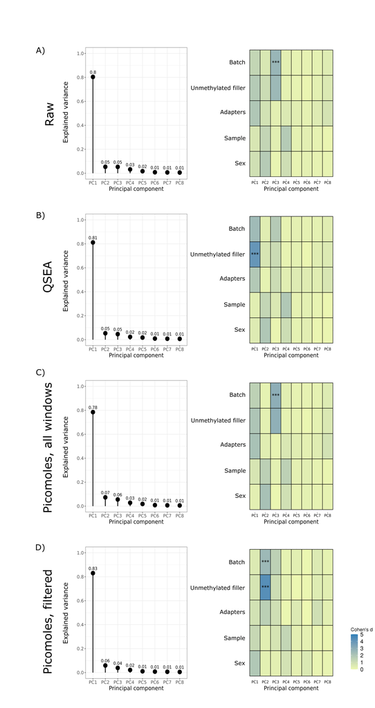

Figure 5